# Supervised Learning_Recell Project

0# Supervised Learning - Foundations: ReCell

*Marks: 60*

## Context

Buying and selling used phones and tablets used to be something that happened on a handful of online marketplace sites. But the used and refurbished device market has grown considerably over the past decade, and a new IDC (International Data Corporation) forecast predicts that the used phone market would be worth \$52.7bn by 2023 with a compound annual growth rate (CAGR) of 13.6% from 2018 to 2023. This growth can be attributed to an uptick in demand for used phones and tablets that offer considerable savings compared with new models.

Refurbished and used devices continue to provide cost-effective alternatives to both consumers and businesses that are looking to save money when purchasing one. There are plenty of other benefits associated with the used device market. Used and refurbished devices can be sold with warranties and can also be insured with proof of purchase. Third-party vendors/platforms, such as Verizon, Amazon, etc., provide attractive offers to customers for refurbished devices. Maximizing the longevity of devices through second-hand trade also reduces their environmental impact and helps in recycling and reducing waste. The impact of the COVID-19 outbreak may further boost this segment as consumers cut back on discretionary spending and buy phones and tablets only for immediate needs.

## Objective

The rising potential of this comparatively under-the-radar market fuels the need for an ML-based solution to develop a dynamic pricing strategy for used and refurbished devices. ReCell, a startup aiming to tap the potential in this market, has hired you as a data scientist. They want you to analyze the data provided and build a linear regression model to predict the price of a used phone/tablet and identify factors that significantly influence it.

## Data Description

The data contains the different attributes of used/refurbished phones and tablets. The detailed data dictionary is given below.

**Data Dictionary**

- brand_name: Name of manufacturing brand
- os: OS on which the device runs
- screen_size: Size of the screen in cm
- 4g: Whether 4G is available or not
- 5g: Whether 5G is available or not
- main_camera_mp: Resolution of the rear camera in megapixels
- selfie_camera_mp: Resolution of the front camera in megapixels
- int_memory: Amount of internal memory (ROM) in GB
- ram: Amount of RAM in GB
- battery: Energy capacity of the device battery in mAh
- weight: Weight of the device in grams
- release_year: Year when the device model was released
- days_used: Number of days the used/refurbished device has been used
- new_price: Price of a new device of the same model in euros
- used_price: Price of the used/refurbished device in euros

## Importing necessary libraries and data

```python
# Libraries to help with reading and manipulating data
import numpy as np
import pandas as pd

# Libraries to help with data visualization
import matplotlib.pyplot as plt
import seaborn as sns

sns.set()

# split the data into train and test
from sklearn.model_selection import train_test_split

# to build linear regression_model
from sklearn.linear_model import LinearRegression

# to check model performance
from sklearn.metrics import mean_absolute_error, mean_squared_error, r2_score

# to build linear regression_model using statsmodels
import statsmodels.api as sm

# to compute VIF
from statsmodels.stats.outliers_influence import variance_inflation_factor

# Removes the limit from the number of displayed columns and rows.
# This is so I can see the entire dataframe when I print it
pd.set_option('display.max_columns', None)
# pd.set_option('display.max_rows', None)
pd.set_option('display.max_rows', 200)
```

## Data Overview

- Observations
- Sanity checks

```python
# loading data
data = pd.read_csv("used_device_data.csv")
```

```python
data.shape # Check the dimension of the dataset
```

```
(3454, 15)
```

### Observations:

- There are 15 columns(features) and 3454 rows in the data

```python
# Look at 10 random rows. Set the random seed via np.random.seed so that I get the same random results every time
np.random.seed(1)
data.sample(n=10)
```

|  | brand_name | os | screen_size | 4g | 5g | main_camera_mp | selfie_camera_mp | int_memory | ram | battery | weight | release_year | days_used | new_price | used_price |
| --- | --- | --- | --- | --- | --- | --- | --- | --- | --- | --- | --- | --- | --- | --- | --- |
| 866 | Others | Android | 15.24 | no | no | 8.00 | 2.0 | 16.0 | 4.00 | 3000.0 | 206.0 | 2014 | 632 | 179.61 | 56.76 |
| 957 | Celkon | Android | 10.16 | no | no | 3.15 | 0.3 | 512.0 | 0.25 | 1400.0 | 140.0 | 2013 | 637 | 48.65 | 16.45 |
| 280 | Infinix | Android | 15.39 | yes | no | NaN | 8.0 | 32.0 | 2.00 | 5000.0 | 185.0 | 2020 | 329 | 88.88 | 79.10 |
| 2150 | Oppo | Android | 12.83 | yes | no | 13.00 | 16.0 | 64.0 | 4.00 | 3200.0 | 148.0 | 2017 | 648 | 281.30 | 107.54 |
| 93 | LG | Android | 15.29 | yes | no | 13.00 | 5.0 | 32.0 | 3.00 | 3500.0 | 179.0 | 2019 | 216 | 200.42 | 91.62 |
| 1040 | Gionee | Android | 12.83 | yes | no | 13.00 | 8.0 | 32.0 | 4.00 | 3150.0 | 166.0 | 2016 | 970 | 279.87 | 104.13 |
| 3170 | ZTE | Others | 10.16 | no | no | 3.15 | 5.0 | 16.0 | 4.00 | 1400.0 | 125.0 | 2014 | 1007 | 69.71 | 43.14 |
| 2742 | Sony | Android | 12.70 | yes | no | 20.70 | 2.0 | 16.0 | 4.00 | 3000.0 | 170.0 | 2013 | 1060 | 330.24 | 83.33 |
| 102 | Meizu | Android | 15.29 | yes | no | NaN | 20.0 | 128.0 | 6.00 | 3600.0 | 165.0 | 2019 | 332 | 420.17 | 142.51 |
| 1195 | HTC | Android | 10.29 | no | no | 8.00 | 2.0 | 32.0 | 4.00 | 2000.0 | 146.0 | 2015 | 892 | 131.50 | 68.57 |

### Observations:

- There are some NaN values in the data set.
- release year is not too old for the models in the dataset.

```python
# Create a copy of the data to avoid any changes to original data
df = data.copy()
```

```python
# checking the column names and datatypes
df.info()
```

```
<class 'pandas.core.frame.DataFrame'>
RangeIndex: 3454 entries, 0 to 3453
Data columns (total 15 columns):
 #   Column            Non-Null Count  Dtype
---  ------            --------------  -----
 0   brand_name        3454 non-null   object
 1   os                3454 non-null   object
 2   screen_size       3454 non-null   float64
 3   4g                3454 non-null   object
 4   5g                3454 non-null   object
 5   main_camera_mp    3275 non-null   float64
 6   selfie_camera_mp  3452 non-null   float64
 7   int_memory        3450 non-null   float64
 8   ram               3450 non-null   float64
 9   battery           3448 non-null   float64
 10  weight            3447 non-null   float64
 11  release_year      3454 non-null   int64
 12  days_used         3454 non-null   int64
 13  new_price         3454 non-null   float64
 14  used_price        3454 non-null   float64
dtypes: float64(9), int64(2), object(4)
memory usage: 404.9+ KB
```

### Observations:

- There are some missing values in the data set.
- Data types varies from Object, Interger and float.

```python
# coverting "objects" to "category" reduces the data space required to store the dataframe

df.brand_name = df.brand_name.astype('category')
df.os = df.os.astype('category')
df["4g"] = df["4g"].astype('category')
df["5g"] = df["5g"].astype('category')

# use info() to print a concise summary of the df1 and check wether the size of df1 been reduced or not.
df.info()
```

```
<class 'pandas.core.frame.DataFrame'>
RangeIndex: 3454 entries, 0 to 3453
Data columns (total 15 columns):
 #   Column            Non-Null Count  Dtype
---  ------            --------------  -----
 0   brand_name        3454 non-null   category
 1   os                3454 non-null   category
 2   screen_size       3454 non-null   float64
 3   4g                3454 non-null   category
 4   5g                3454 non-null   category
 5   main_camera_mp    3275 non-null   float64
 6   selfie_camera_mp  3452 non-null   float64
 7   int_memory        3450 non-null   float64
 8   ram               3450 non-null   float64
 9   battery           3448 non-null   float64
 10  weight            3447 non-null   float64
 11  release_year      3454 non-null   int64
 12  days_used         3454 non-null   int64
 13  new_price         3454 non-null   float64
 14  used_price        3454 non-null   float64
dtypes: category(4), float64(9), int64(2)
memory usage: 312.2 KB
```

### Observation:

- after converting the data type from Object to Category the size is reduced.

```python
df.describe().T
```

|  | count | mean | std | min | 25% | 50% | 75% | max |
| --- | --- | --- | --- | --- | --- | --- | --- | --- |
| screen_size | 3454.0 | 13.713115 | 3.805280 | 5.08 | 12.7000 | 12.830 | 15.340 | 30.71 |
| main_camera_mp | 3275.0 | 9.460208 | 4.815461 | 0.08 | 5.0000 | 8.000 | 13.000 | 48.00 |
| selfie_camera_mp | 3452.0 | 6.554229 | 6.970372 | 0.00 | 2.0000 | 5.000 | 8.000 | 32.00 |
| int_memory | 3450.0 | 54.573099 | 84.972371 | 0.01 | 16.0000 | 32.000 | 64.000 | 1024.00 |
| ram | 3450.0 | 4.036122 | 1.365105 | 0.02 | 4.0000 | 4.000 | 4.000 | 12.00 |
| battery | 3448.0 | 3133.402697 | 1299.682844 | 500.00 | 2100.0000 | 3000.000 | 4000.000 | 9720.00 |
| weight | 3447.0 | 182.751871 | 88.413228 | 69.00 | 142.0000 | 160.000 | 185.000 | 855.00 |
| release_year | 3454.0 | 2015.965258 | 2.298455 | 2013.00 | 2014.0000 | 2015.500 | 2018.000 | 2020.00 |
| days_used | 3454.0 | 674.869716 | 248.580166 | 91.00 | 533.5000 | 690.500 | 868.750 | 1094.00 |
| new_price | 3454.0 | 237.038848 | 194.302782 | 18.20 | 120.3425 | 189.785 | 291.115 | 2560.20 |
| used_price | 3454.0 | 92.302936 | 54.701648 | 4.65 | 56.4825 | 81.870 | 116.245 | 749.52 |

### Observation:

```python
df.describe(include="category").T # describe for non-numeric values
```

|  | count | unique | top | freq |
| --- | --- | --- | --- | --- |
| brand_name | 3454 | 34 | Others | 502 |
| os | 3454 | 4 | Android | 3214 |
| 4g | 3454 | 2 | yes | 2335 |
| 5g | 3454 | 2 | no | 3302 |

### Observation

```python
# Check the count of missing values.
df.isnull().sum().sort_values(ascending=False)
```

```
main_camera_mp      179
weight                7
battery               6
int_memory            4
ram                   4
selfie_camera_mp      2
brand_name            0
os                    0
screen_size           0
4g                    0
5g                    0
release_year          0
days_used             0
new_price             0
used_price            0
dtype: int64
```

### Observation:

- There are high number of missing values in main_camera_mp column, the count is 179.
- And very few missing values in weight, battery, int_memory, ram, selfie_camera_mp.

```python
# checking for duplicate values in the data
df.duplicated().sum()
```

```
0
```

### Observation:

There are no duplicates in the data set.

## Exploratory Data Analysis (EDA)

- EDA is an important part of any project involving data.
- It is important to investigate and understand the data better before building a model with it.
- A few questions have been mentioned below which will help you approach the analysis in the right manner and generate insights from the data.
- A thorough analysis of the data, in addition to the questions mentioned below, should be done.

**Questions**:

1. What does the distribution of used device prices look like?
2. What percentage of the used device market is dominated by Android devices?
3. The amount of RAM is important for the smooth functioning of a device. How does the amount of RAM vary with the brand?
4. A large battery often increases a device's weight, making it feel uncomfortable in the hands. How does the weight vary for phones and tablets offering large batteries (more than 4500 mAh)?
5. Bigger screens are desirable for entertainment purposes as they offer a better viewing experience. How many phones and tablets are available across different brands with a screen size larger than 6 inches?
6. Budget devices nowadays offer great selfie cameras, allowing us to capture our favorite moments with loved ones. What is the distribution of budget devices offering greater than 8MP selfie cameras across brands?
7. Which attributes are highly correlated with the price of a used device?

# EDA - Univariate Analysis

```python
# function to plot a boxplot and a histogram along the same scale.


def histogram_boxplot(data, feature, figsize=(12, 7), kde=False, bins=None):
    """
    Boxplot and histogram combined

    data: dataframe
    feature: dataframe column
    figsize: size of figure (default (12,7))
    kde: whether to the show density curve (default False)
    bins: number of bins for histogram (default None)
    """
    f2, (ax_box2, ax_hist2) = plt.subplots(
        nrows=2,  # Number of rows of the subplot grid= 2
        sharex=True,  # x-axis will be shared among all subplots
        gridspec_kw={"height_ratios": (0.25, 0.75)},
        figsize=figsize,
    )  # creating the 2 subplots
    sns.boxplot(
        data=data, x=feature, ax=ax_box2, showmeans=True, color="violet"
    )  # boxplot will be created and a star will indicate the mean value of the column
    sns.histplot(
        data=data, x=feature, kde=kde, ax=ax_hist2, bins=bins, palette="winter"
    ) if bins else sns.histplot(
        data=data, x=feature, kde=kde, ax=ax_hist2
    )  # For histogram
    ax_hist2.axvline(
        data[feature].mean(), color="green", linestyle="--"
    )  # Add mean to the histogram
    ax_hist2.axvline(
        data[feature].median(), color="black", linestyle="-"
    )  # Add median to the histogram
```

```python
df.columns
```

```
Index(['brand_name', 'os', 'screen_size', '4g', '5g', 'main_camera_mp',
       'selfie_camera_mp', 'int_memory', 'ram', 'battery', 'weight',
       'release_year', 'days_used', 'new_price', 'used_price'],
      dtype='object')
```

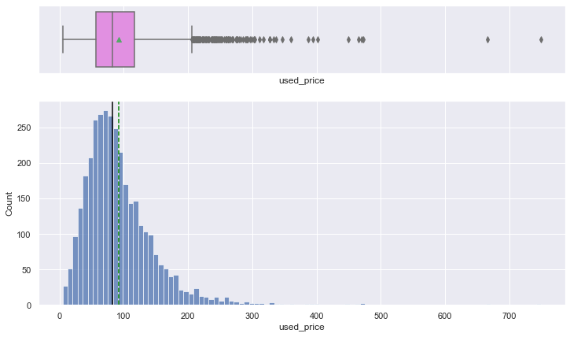

```python
histogram_boxplot(df, "used_price") # price column
```

### Observations:

- The distribution of used price is right skewed, it looks like there are many outliers in the used_price.

```python
df["used_price_log"] = np.log(df["used_price"]) # used_price column
```

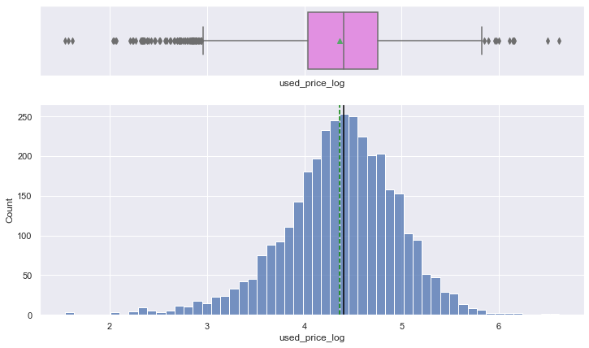

```python
histogram_boxplot(df,"used_price_log")
```

### Observations:

- Boxplot of the used price still shows some outliers on both the side.
- the distribution now looks like more a kind of normal distribution.

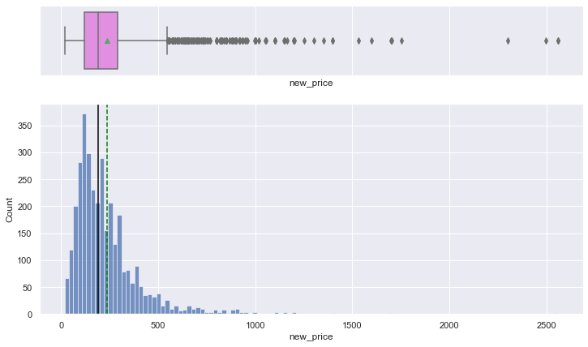

```python
histogram_boxplot(df, "new_price") # New price_column
```

### Observations:

- New_price feature has many outliers and it is highly right skewed.
- The mean value of the new_price lies around 250$

```python
df["new_price_log"] = np.log(df["new_price"]) # cal. of log for new_price
```

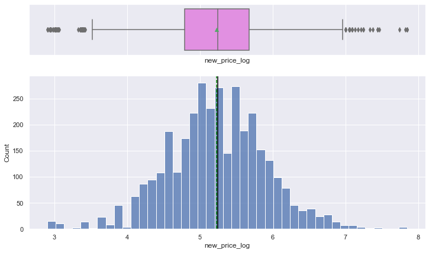

```python
histogram_boxplot(df, "new_price_log") # plot the log values of new price
```

### Observations:

- Still the new_price_log is not normally distributed and there are many outliers spread accross both sides of the boxplot.

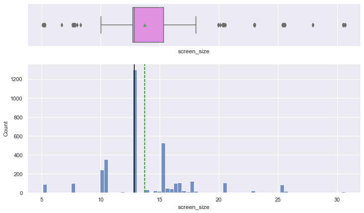

```python
histogram_boxplot(df, "screen_size") # plotting of screen size column
```

### Observations:

- The data is not normally distributed and the curve is highly skewed on both the sides.

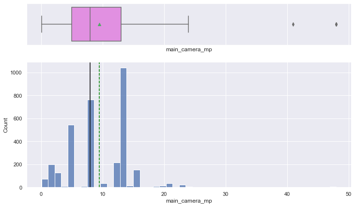

```python
histogram_boxplot(df, "main_camera_mp") # hist_boxplot of main_camera_mp column
```

### Observation:

- main_camera_mp has 2 outliers and the distribution is not normal.
- Avgerage screen size is around 9 MP.

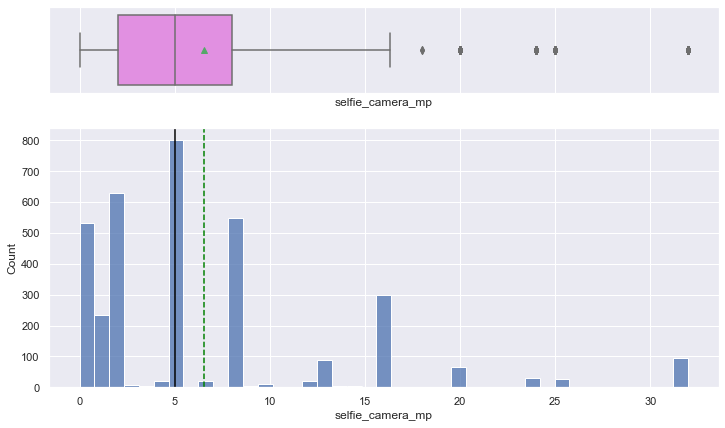

```python
histogram_boxplot(df, "selfie_camera_mp") # plotting selfie_camera_mp column
```

### Observations:

- The distribution of the selfie camera_mp is not normal and it has few outliers on the right side.
- Avg. MP of the selfie camera is 6.5.

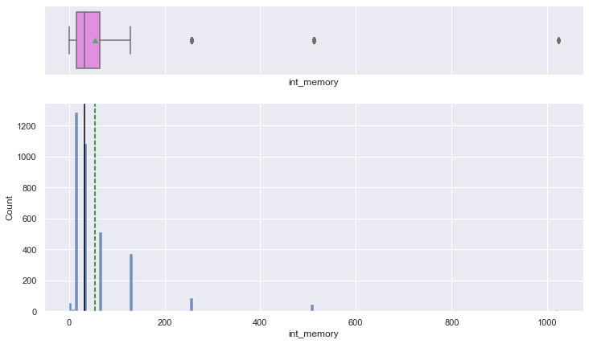

```python
histogram_boxplot(df, "int_memory") # plotting of int_memory column
```

### Observations:

- int_memory has few outliers on the right side.
- The distribution is not normal.
- Avg. internal memory size is around 50 GB.

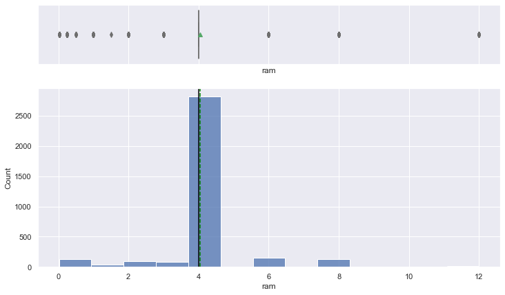

```python
histogram_boxplot(df, "ram") # his_box plot of "ram" column
```

### Observations:

- The "ram" feature has so many outliers
- The distribution is not normal
- The Mean ram size is 4 GB. Mean and Median lies at the same level.

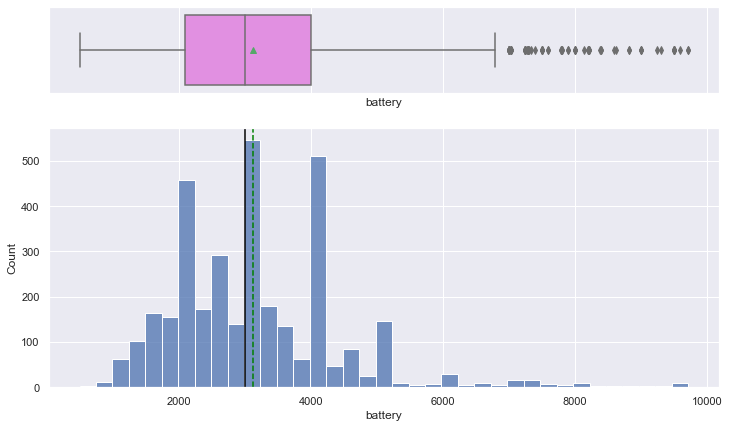

```python
histogram_boxplot(df, "battery") # hist_box plot "battery" column
```

### Observations:

- The "Battery" feature has outliers in it.
- The distribution is not normal. and it is highly right skewed.
- The avg. battery capacity is around 3200 mAh.

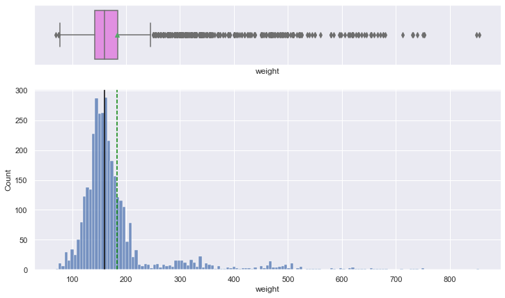

```python
histogram_boxplot(df, "weight") # hist_box plot of "weight" column.
```

### Observation:

- The "weight" feature has so many outliers on the right side.
- The distribution is slightly following the normal distribution and it is highly right skewed.
- The avg. weight of the phone is around 190 grams.

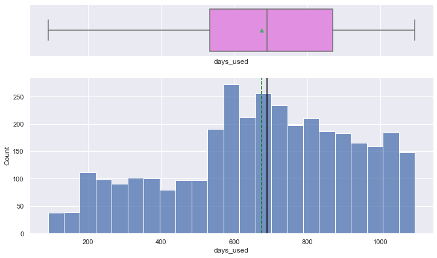

```python
histogram_boxplot(df, "days_used") # hist_box plot of days_used column
```

### Observation:

- days_used feature has no outliers in it.
- The distribution is not normal.
- The average number of days used is around 670 days.

## EDA for categorical variable:

```python
# function to create labeled barplots


def labeled_barplot(data, feature, perc=False, n=None):
    """
    Barplot with percentage at the top

    data: dataframe
    feature: dataframe column
    perc: whether to display percentages instead of count (default is False)
    n: displays the top n category levels (default is None, i.e., display all levels)
    """

    total = len(data[feature])  # length of the column
    count = data[feature].nunique()
    if n is None:
        plt.figure(figsize=(count + 1, 5))
    else:
        plt.figure(figsize=(n + 1, 5))

    plt.xticks(rotation=90, fontsize=15)
    ax = sns.countplot(
        data=data,
        x=feature,
        palette="Paired",
        order=data[feature].value_counts().index[:n].sort_values(),
    )

    for p in ax.patches:
        if perc == True:
            label = "{:.1f}%".format(
                100 * p.get_height() / total
            )  # percentage of each class of the category
        else:
            label = p.get_height()  # count of each level of the category

        x = p.get_x() + p.get_width() / 2  # width of the plot
        y = p.get_height()  # height of the plot

        ax.annotate(
            label,
            (x, y),
            ha="center",
            va="center",
            size=12,
            xytext=(0, 5),
            textcoords="offset points",
        )  # annotate the percentage

    plt.show()  # show the plot
```

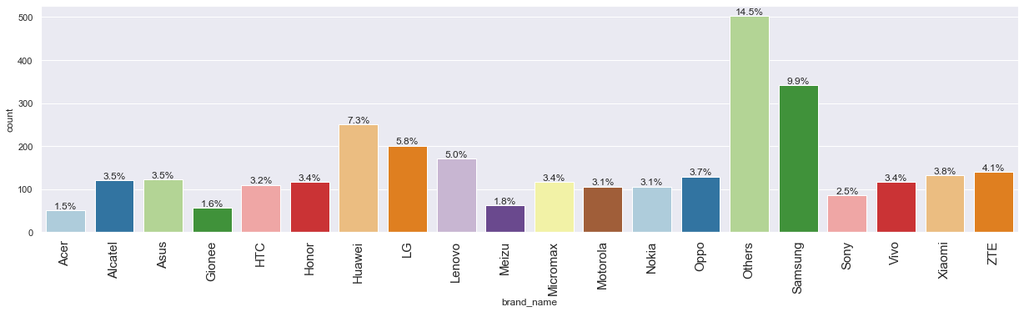

```python
labeled_barplot(df, "brand_name", perc=True, n=20) # labeled bar plot for "brand_name"
```

### Observation:

- 14.5% of the used devices has no specific brand names given.
- 9.9% of the used devised are from "samsung"

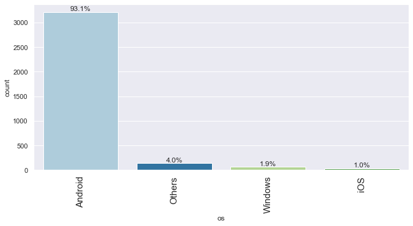

```python
labeled_barplot(df, "os", perc=True, n=10) # labeled bar plot for "os"
```

### Observation:

- The phones with the Android OS is the mostly selling devices in the used market and the percentage is 93.1.

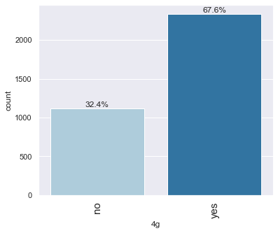

```python
labeled_barplot(df, "4g", perc=True, n=5) # labeled bar plot for "4g"
```

### Observation:

- 67.6% of the devices got 4g feature in it.

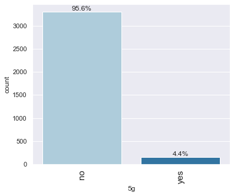

```python
labeled_barplot(df, "5g", perc=True, n=5) # labelled bar plot for "5g"
```

### Observations:

- 95.6% of the phones in the data set has no 5g feature.
- Only 4.4% of the phones got 5g feature.

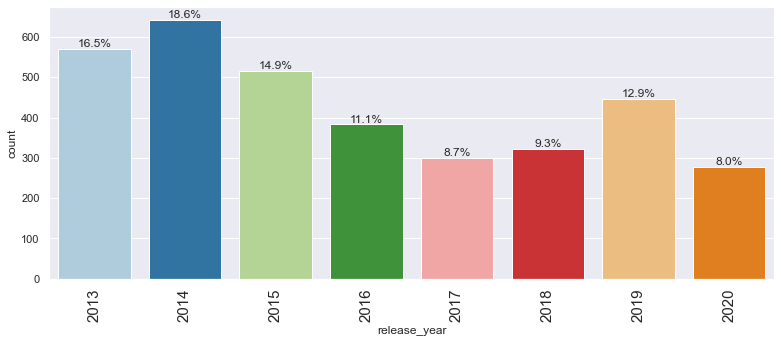

```python
labeled_barplot(df, "release_year", perc=True, n=12) # labelled bar plot for "release year"
```

### Observations:

- 8% of the phones are very new and it came to the market to be sold on seconds in 2020.
- 2014 has good inventory on devices. The percentage of the used devices from 2014 is 18.6.

# EDA - Bivariate Analysis

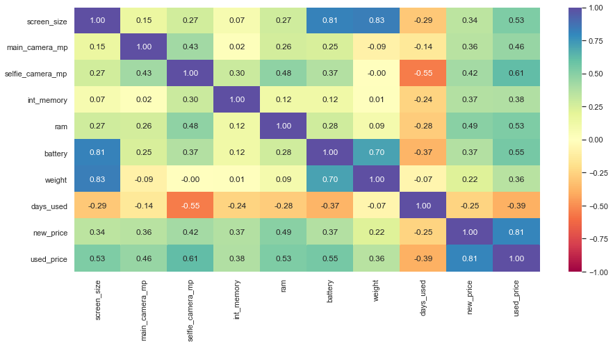

```python
cols_list = df.select_dtypes(include=np.number).columns.tolist()
# dropping release_year as it is a temporal variable.

cols_list.remove("release_year")

cols_list.remove("used_price_log")
cols_list.remove("new_price_log")

plt.figure(figsize=(15, 7))
sns.heatmap(
    df[cols_list].corr(), annot=True, vmin=-1, vmax=1, fmt=".2f", cmap="Spectral"
)
plt.show()
```

### Observation:

- The screen_size is highly positively related to "weight" and the "battery" feature.
- used_price is positively and reasonably correlated to "screen_size", "selfie_camera", "ram", "battery", "new_price".
- "batter" and "weight" of the phone is highly positively correlated.

### 3. The amount of RAM is important for the smooth functioning of a device. Let's see how the amount of RAM varies across brands.

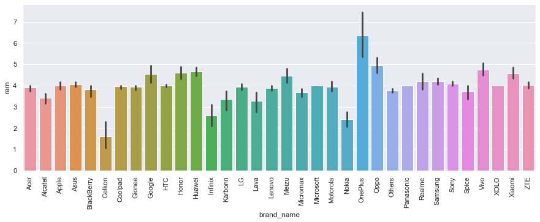

```python
plt.figure(figsize=(15, 5))
sns.barplot(data=df, x="brand_name", y="ram") # plot bar from seaborn library
plt.xticks(rotation=90)
plt.show()
```

### **4. People who travel frequently require devices with large batteries to run through the day. But large battery often increases a device's weight, making it feel uncomfortable in the hands. Let's create a new dataframe of only those devices which offer a large battery and analyze.**

```python
df_large_battery = df[df.battery > 4500] # creating the dataset of >4500 mAh
df_large_battery.shape
```

```
(341, 17)
```

### Observations:

- 341 devices got more than 4500 mAh battery size is useful for the frequent travellers to have longlasting battery for use.

```python
df_large_battery.groupby("brand_name")["weight"].mean().sort_values(ascending=False) # grouping the dataset of largebatteries based on "brand_name" and its "weight"
```

```
brand_name
Google        517.000000
Lenovo        442.721429
Apple         439.558824
Sony          439.500000
HTC           425.000000
Samsung       398.352000
Huawei        394.486486
Others        390.546341
Alcatel       380.000000
LG            366.058333
Acer          360.000000
Nokia         318.000000
Asus          313.772727
Honor         248.714286
Xiaomi        231.500000
Gionee        209.430000
Motorola      200.757143
Realme        196.833333
Vivo          195.630769
ZTE           195.400000
Oppo          195.000000
Infinix       193.000000
Panasonic     182.000000
Spice         158.000000
Micromax      118.000000
BlackBerry           NaN
Celkon               NaN
Coolpad              NaN
Karbonn              NaN
Lava                 NaN
Meizu                NaN
Microsoft            NaN
OnePlus              NaN
XOLO                 NaN
Name: weight, dtype: float64
```

### Observations:

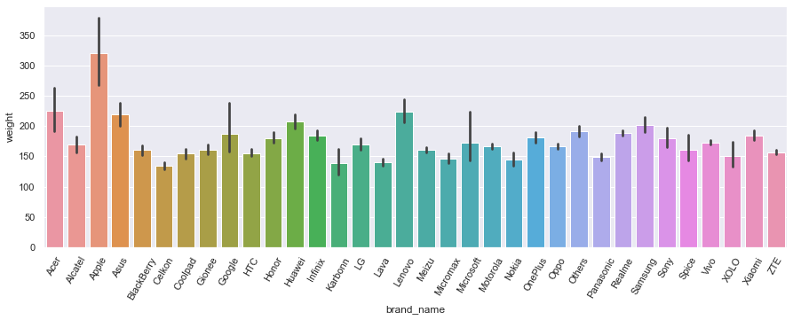

```python
plt.figure(figsize=(15, 5))
sns.barplot(data=df, x="brand_name", y="weight") ##  barplot for 'brand_name' and 'weight'
plt.xticks(rotation=60)
plt.show()
```

### Observations:

- Weight of the Apple phones is higher than any other brands in the dataframe, f0llowing which Acer, Asus, Lenovo are the more weighted phones.
- Celkon, Karbonn, Lava, Micromax, Nokia are some least weighted phones.

### 5. Bigger screens are desirable for entertainment purposes as they offer a better viewing experience. How many phones and tablets are available across different brands with a screen size larger than 6 inches?

```python
df_large_screen = df[df.screen_size > 6 * 2.54] # data set of >6 inches screen size
df_large_screen.shape
```

```
(1099, 17)
```

### Observation:

- There are 1099 devices has more than 6 inches of screen size.

```python
df_large_screen.brand_name.value_counts().sort_values(ascending=False) # printing the large screens on descending order
```

```
Huawei        149
Samsung       119
Others         99
Vivo           80
Honor          72
Oppo           70
Lenovo         69
Xiaomi         69
LG             59
Motorola       42
Asus           41
Realme         40
Alcatel        26
Apple          24
Acer           19
Meizu          17
ZTE            17
OnePlus        16
Nokia          15
Sony           12
Infinix        10
Micromax        7
HTC             7
Google          4
XOLO            3
Gionee          3
Coolpad         3
Spice           2
Panasonic       2
Karbonn         2
Microsoft       1
Celkon          0
BlackBerry      0
Lava            0
Name: brand_name, dtype: int64
```

### Observation:

- Huawei , Samsung phones got bigger size screens in large numbers.
- There are no phones from Celkon, BalckBerry and Lava with more than 6 inches in screen size.

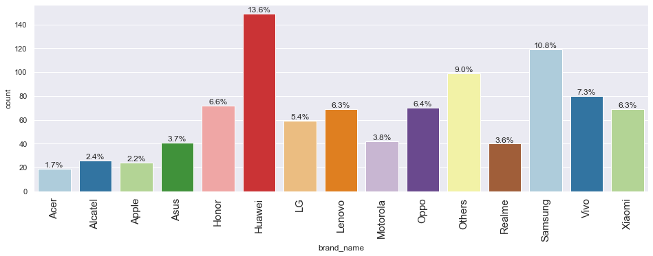

```python
labeled_barplot(df_large_screen, "brand_name", perc=True, n=15) # plotting largescreens using barplot.
```

## **Check on the brandwise age of the devised in Used_Market**

```python
df_less_days = df[df.days_used < 365] # checking the devices used less than 365 days
df_less_days.shape
```

```
(508, 17)
```

### Observation:

- There 508 phone in the data set is less than a year old available for sale.

```python
df_less_days.brand_name.value_counts().sort_values(ascending=False) # printing the least used devices in descending order.
```

```
Huawei        74
Honor         56
Samsung       44
Xiaomi        37
Vivo          37
Oppo          36
LG            30
Realme        30
Others        30
Motorola      30
Nokia         26
ZTE           11
Meizu         10
Apple          8
Infinix        8
OnePlus        7
Alcatel        7
Lenovo         7
Sony           7
HTC            4
Google         3
Lava           2
Coolpad        2
Asus           2
Celkon         0
Micromax       0
Microsoft      0
Panasonic      0
XOLO           0
BlackBerry     0
Gionee         0
Spice          0
Karbonn        0
Acer           0
Name: brand_name, dtype: int64
```

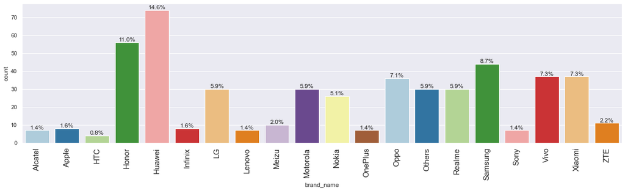

```python
labeled_barplot(df_less_days, "brand_name", perc=True, n=20) # plotting the least used devise using bar_plot
```

### Observation:

- 14.6% of the phones with less than a year is from Huawei brand and 11% of the phones from Honor Brand.

## Data Preprocessing

1. Feature engineering (if needed)
2. Missing value treatment
3. Outlier detection and treatment (if needed)
4. Preparing data for modeling
5. Any other preprocessing steps (if needed)

## 1. Featured Engineering

- Let's create a new column `device_category` from the `new_price` column to tag devices as budget, mid-ranger, or premium.

```python
df["device_category"] = pd.cut(
    x=df.new_price,
    bins=[-np.infty, 200, 350, np.infty],
    labels=["Budget", "Mid_ranger", "Premium"],
)

df["device_category"].value_counts() # creating the device category based on the price values
```

```
Budget        1844
Mid_ranger    1025
Premium        585
Name: device_category, dtype: int64
```

### Observation:

- There are 1844 phones are in lower bedget of 200 Euros
- 1025 phones in the budget of Mid_ranger costs between 200 to 350 Euros
- 585 phones are in the Premium range, costs more than 350 Euros

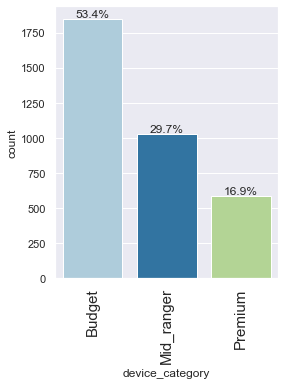

```python
labeled_barplot(df,'device_category',perc=True) # plotting the device category
```

### Obsevation:

- 53.4% of the phones are cheaper range, 29.7% of the phones in Mid_range and 16.9% of the phones in Premium range.

### **6. Everyone likes a good camera to capture their favorite moments with loved ones. Some customers specifically look for good front cameras to click cool selfies. Let's create a new dataframe of only those devices which are suitable for this customer segment and analyze.**

```python
df_selfie_camera =df[df.selfie_camera_mp>8] ## create a dataframe having selfie_camera_mp > 8
df_selfie_camera.shape
```

```
(655, 18)
```

### Onservations:

There are 655 phones got more than 8 MP in the dataset.

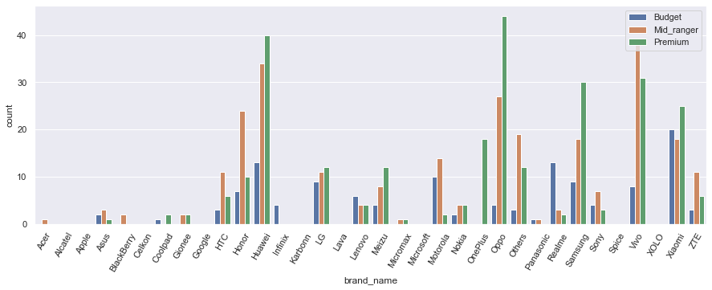

```python
plt.figure(figsize=(15, 5))
sns.countplot(data=df_selfie_camera,x="brand_name",hue="device_category") ## countplot for 'brandname' with hue = 'device_category' on df_selfie_camera
plt.xticks(rotation=60)
plt.legend(loc=1)
plt.show()
```

### Observations:

- From the above graph, premium and and Mid_ranger phones got high ratio of better selfie_camera.

```python
df_main_camera = df[df.main_camera_mp>16] ## create a dataframe having main_camera_mp > 16
df_main_camera.shape
```

```
(94, 18)
```

### Observations:

- There are 94 phones got more than 16 rear camera MPs.

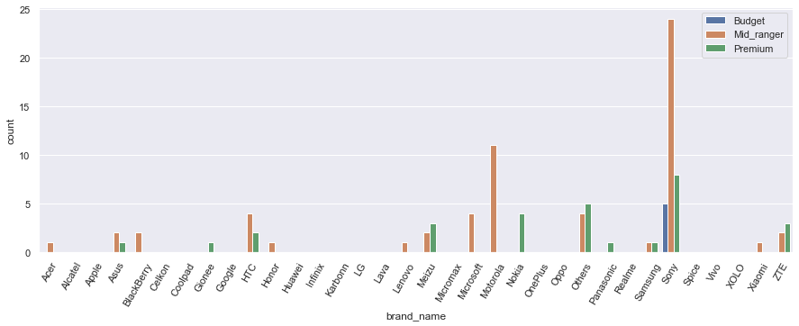

```python
plt.figure(figsize=(15, 5))
sns.countplot(data=df_main_camera,x="brand_name",hue="device_category") ## create countplot for 'brandname' with hue = 'device_category' on df_selfie_camera
plt.xticks(rotation=60)
plt.legend(loc=1)
plt.show() # brandwise countplot for >16 MP devices based on device_category
```

### 7. Which attributes are highly correlated with the price of a used device

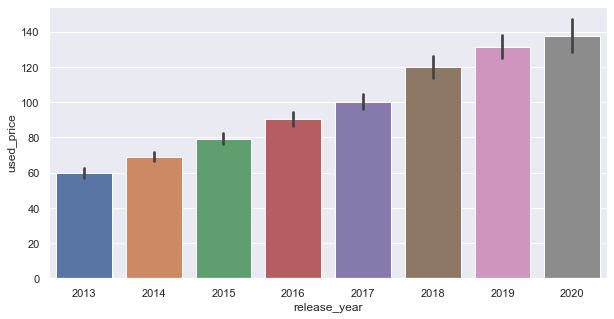

```python
plt.figure(figsize=(10, 5))
sns.barplot(data=df, x="release_year", y="used_price") ## barplot for release year and used price
plt.show()
```

### Observation:

- Based on the barplot Price of the used_devices are higher for the recently released years.

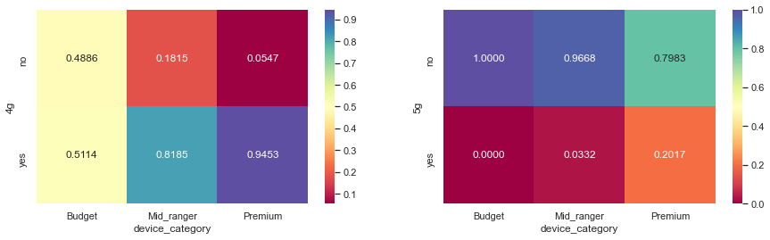

```python
plt.figure(figsize=(15, 4))

plt.subplot(121)
sns.heatmap(
    pd.crosstab(df["4g"], df["device_category"], normalize="columns"),
    annot=True,
    fmt=".4f",
    cmap="Spectral",
) ## Crosstab for 4g

plt.subplot(122)
sns.heatmap(pd.crosstab(df["5g"], df["device_category"], normalize="columns"),
    annot=True,
    fmt=".4f",
    cmap="Spectral", ) ## crosstab for 5g.

plt.show()
```

## 2. Missing Value Imputation

- We will impute the missing values in the data by the column medians grouped by `release_year` and `brand_name`.

```python
df1=df.copy() # Copying the current dataset in the new name to avoid any data-corruption
```

```python
df1.columns # Check the columns names.
```

```
Index(['brand_name', 'os', 'screen_size', '4g', '5g', 'main_camera_mp',
       'selfie_camera_mp', 'int_memory', 'ram', 'battery', 'weight',
       'release_year', 'days_used', 'new_price', 'used_price',
       'used_price_log', 'new_price_log', 'device_category'],
      dtype='object')
```

```python
df1.isnull().sum().sort_values(ascending=False) # get the count of missing values sorted in descending order.
```

```
main_camera_mp      179
weight                7
battery               6
int_memory            4
ram                   4
selfie_camera_mp      2
days_used             0
new_price_log         0
used_price_log        0
used_price            0
new_price             0
brand_name            0
release_year          0
os                    0
5g                    0
4g                    0
screen_size           0
device_category       0
dtype: int64
```

### Observations:

- There are some missing values in main_camera_mp, weight, battery, int_memory, ram, selfie_camera_mp.

```python
cols_impute = [
    "screen_size",
    "main_camera_mp",
    "selfie_camera_mp",
    "int_memory",
    "ram",
    "battery",
    "weight",
]

for col in cols_impute:
    df1[col] = df1.groupby(['release_year', "brand_name"])[col].transform(
        lambda x: x.fillna(x.median())
    )   ## impute missing values in cols_impute with median by grouping the data on release year and brand name
```

```python
df1.isnull().sum()
```

```
brand_name            0
os                    0
screen_size           0
4g                    0
5g                    0
main_camera_mp      179
selfie_camera_mp      2
int_memory            0
ram                   0
battery               6
weight                7
release_year          0
days_used             0
new_price             0
used_price            0
used_price_log        0
new_price_log         0
device_category       0
dtype: int64
```

```python
cols_impute = [
    "screen_size",
    "main_camera_mp",
    "selfie_camera_mp",
    "int_memory",
    "ram",
    "battery",
    "weight",
]

for col in cols_impute:
    df1[col] = df1.groupby(['brand_name'])[col].transform(
        lambda x: x.fillna(x.median())
    ) ## Complete the code to impute the missing values in cols_impute with median by grouping the data on brand name
```

```python
df1.isnull().sum()
```

```
brand_name           0
os                   0
screen_size          0
4g                   0
5g                   0
main_camera_mp      10
selfie_camera_mp     0
int_memory           0
ram                  0
battery              0
weight               0
release_year         0
days_used            0
new_price            0
used_price           0
used_price_log       0
new_price_log        0
device_category      0
dtype: int64
```

### Observations:

- We can notice that missing values were almost filled except main_camera_mp.

```python
df1["main_camera_mp"] = df1["main_camera_mp"].fillna(df1["main_camera_mp"].median()) ## impute the data with median

# checking for missing values
df1.isnull().sum() ## check missing values after imputing the above columns
```

```
brand_name          0
os                  0
screen_size         0
4g                  0
5g                  0
main_camera_mp      0
selfie_camera_mp    0
int_memory          0
ram                 0
battery             0
weight              0
release_year        0
days_used           0
new_price           0
used_price          0
used_price_log      0
new_price_log       0
device_category     0
dtype: int64
```

### Observations:

- Now there are no missing values in the dataset.

## 2. Outlier Check

```python
df1.info()
```

```
<class 'pandas.core.frame.DataFrame'>
RangeIndex: 3454 entries, 0 to 3453
Data columns (total 18 columns):
 #   Column            Non-Null Count  Dtype
---  ------            --------------  -----
 0   brand_name        3454 non-null   category
 1   os                3454 non-null   category
 2   screen_size       3454 non-null   float64
 3   4g                3454 non-null   category
 4   5g                3454 non-null   category
 5   main_camera_mp    3454 non-null   float64
 6   selfie_camera_mp  3454 non-null   float64
 7   int_memory        3454 non-null   float64
 8   ram               3454 non-null   float64
 9   battery           3454 non-null   float64
 10  weight            3454 non-null   float64
 11  release_year      3454 non-null   int64
 12  days_used         3454 non-null   int64
 13  new_price         3454 non-null   float64
 14  used_price        3454 non-null   float64
 15  used_price_log    3454 non-null   float64
 16  new_price_log     3454 non-null   float64
 17  device_category   3454 non-null   category
dtypes: category(5), float64(11), int64(2)
memory usage: 369.7 KB
```

```python
# outlier detection using boxplot
numeric_columns = df1.select_dtypes(include=np.number).columns.tolist()
# dropping release_year as it is a temporal variable
numeric_columns.remove("release_year")
```

```python
numeric_columns
```

```
['screen_size',
 'main_camera_mp',
 'selfie_camera_mp',
 'int_memory',
 'ram',
 'battery',
 'weight',
 'days_used',
 'new_price',
 'used_price',
 'used_price_log',
 'new_price_log']
```

## 1. Outlier Check on Screen size:

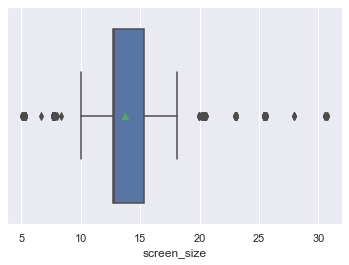

```python
sns.boxplot(data=df1, x="screen_size", showmeans=True) # boxplot for "screensize" to check outliers
```

```python
df1[df1["screen_size"]>25].describe()
```

|  | screen_size | main_camera_mp | selfie_camera_mp | int_memory | ram | battery | weight | release_year | days_used | new_price | used_price | used_price_log | new_price_log |
| --- | --- | --- | --- | --- | --- | --- | --- | --- | --- | --- | --- | --- | --- |
| count | 120.000000 | 120.000000 | 120.000000 | 120.000000 | 120.000000 | 120.000000 | 120.000000 | 120.000000 | 120.000000 | 120.000000 | 120.000000 | 120.000000 | 120.000000 |
| mean | 25.989667 | 7.526250 | 3.668333 | 55.866667 | 4.025000 | 6617.562500 | 518.544167 | 2016.000000 | 661.466667 | 354.401833 | 152.960583 | 4.972636 | 5.755362 |
| std | 1.521767 | 3.375704 | 2.658710 | 130.463616 | 0.793487 | 1928.537993 | 131.109374 | 2.452918 | 254.177399 | 191.899859 | 58.789047 | 0.327494 | 0.463842 |
| min | 25.400000 | 0.300000 | 0.300000 | 16.000000 | 1.000000 | 1200.000000 | 130.400000 | 2013.000000 | 139.000000 | 98.890000 | 71.370000 | 4.267878 | 4.594008 |
| 25% | 25.430000 | 5.000000 | 2.000000 | 16.000000 | 4.000000 | 6000.000000 | 467.750000 | 2014.000000 | 511.750000 | 230.027500 | 115.295000 | 4.747491 | 5.438199 |
| 50% | 25.430000 | 8.000000 | 2.000000 | 32.000000 | 4.000000 | 7000.000000 | 506.600000 | 2015.000000 | 654.000000 | 298.860000 | 141.355000 | 4.951271 | 5.699975 |
| 75% | 25.530000 | 8.100000 | 5.100000 | 64.000000 | 4.000000 | 7653.000000 | 600.275000 | 2018.000000 | 891.250000 | 405.105000 | 174.610000 | 5.162555 | 6.003964 |
| max | 30.710000 | 13.000000 | 8.000000 | 1024.000000 | 6.000000 | 9720.000000 | 855.000000 | 2020.000000 | 1089.000000 | 1100.860000 | 472.940000 | 6.158969 | 7.003847 |

## Observation:

- The outliers are not the mistaken values, hence decided to keep those

## 2. Outlier Check on main_camera_mp

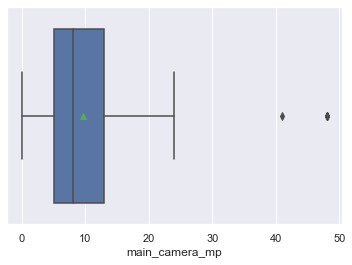

```python
sns.boxplot(data=df1, x="main_camera_mp", showmeans=True) # box_plot for main_camera MP.
```

```python
df1[df1["main_camera_mp"]>40]
```

|  | brand_name | os | screen_size | 4g | 5g | main_camera_mp | selfie_camera_mp | int_memory | ram | battery | weight | release_year | days_used | new_price | used_price | used_price_log | new_price_log | device_category |
| --- | --- | --- | --- | --- | --- | --- | --- | --- | --- | --- | --- | --- | --- | --- | --- | --- | --- | --- |
| 210 | ZTE | Android | 16.89 | yes | no | 48.0 | 16.0 | 128.0 | 8.0 | 5000.0 | 215.0 | 2019 | 336 | 819.57 | 289.47 | 5.668052 | 6.708780 | Premium |
| 215 | ZTE | Android | 16.89 | yes | no | 48.0 | 16.0 | 64.0 | 6.0 | 5000.0 | 215.0 | 2019 | 506 | 501.56 | 193.20 | 5.263726 | 6.217723 | Premium |
| 2097 | Nokia | Windows | 10.29 | yes | no | 41.0 | 1.2 | 32.0 | 4.0 | 2000.0 | 158.0 | 2013 | 988 | 399.13 | 164.86 | 5.105097 | 5.989287 | Premium |
| 3240 | Motorola | Android | 15.34 | yes | no | 48.0 | 25.0 | 128.0 | 4.0 | 3600.0 | 165.0 | 2019 | 371 | 254.99 | 205.60 | 5.325933 | 5.541224 | Mid_ranger |
| 3381 | Motorola | Android | 15.34 | yes | no | 48.0 | 25.0 | 128.0 | 4.0 | 3600.0 | 165.0 | 2019 | 422 | 254.99 | 206.65 | 5.331027 | 5.541224 | Mid_ranger |

## Observations:

- As per the research on these outlier datas, these are the actual values and need not to be treated.

## 3. Outlier Check on selfie_camera_mp

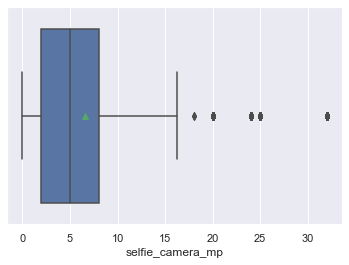

```python
sns.boxplot(data=df1, x="selfie_camera_mp", showmeans=True) # box_plot for "selfie_camera_mp".
```

```python
selfie_outliers=df1[df1["selfie_camera_mp"]>25]
```

```python
selfie_outliers.sample(n=10)
```

|  | brand_name | os | screen_size | 4g | 5g | main_camera_mp | selfie_camera_mp | int_memory | ram | battery | weight | release_year | days_used | new_price | used_price | used_price_log | new_price_log | device_category |
| --- | --- | --- | --- | --- | --- | --- | --- | --- | --- | --- | --- | --- | --- | --- | --- | --- | --- | --- |
| 260 | Huawei | Android | 15.90 | yes | no | 13.0 | 32.0 | 64.0 | 6.0 | 4000.0 | 178.0 | 2019 | 351 | 200.28 | 154.03 | 5.037147 | 5.299716 | Mid_ranger |
| 3342 | Honor | Android | 15.77 | yes | no | 13.0 | 32.0 | 128.0 | 4.0 | 3400.0 | 164.0 | 2019 | 355 | 137.70 | 49.55 | 3.902982 | 4.925077 | Budget |
| 3362 | LG | Android | 15.34 | yes | no | 8.0 | 32.0 | 128.0 | 6.0 | 4000.0 | 192.0 | 2019 | 193 | 722.50 | 250.68 | 5.524177 | 6.582717 | Premium |
| 3360 | Lenovo | Android | 16.23 | yes | no | 8.0 | 32.0 | 128.0 | 6.0 | 4000.0 | 185.0 | 2019 | 446 | 373.92 | 200.10 | 5.298817 | 5.924042 | Premium |
| 365 | Samsung | Android | 15.37 | yes | yes | 8.0 | 32.0 | 128.0 | 6.0 | 4500.0 | 187.0 | 2020 | 248 | 429.21 | 168.39 | 5.126283 | 6.061946 | Premium |
| 3214 | Huawei | Android | 15.90 | yes | no | 13.0 | 32.0 | 128.0 | 6.0 | 3750.0 | 174.0 | 2019 | 489 | 203.15 | 144.72 | 4.974801 | 5.313945 | Mid_ranger |
| 3340 | Honor | Android | 15.90 | yes | no | 13.0 | 32.0 | 128.0 | 8.0 | 4000.0 | 182.0 | 2019 | 431 | 314.87 | 207.30 | 5.334167 | 5.752160 | Mid_ranger |
| 272 | Huawei | Android | 16.23 | yes | no | 13.0 | 32.0 | 128.0 | 8.0 | 3500.0 | 171.0 | 2019 | 210 | 359.22 | 214.09 | 5.366396 | 5.883935 | Premium |
| 3203 | Huawei | Android | 16.59 | yes | yes | 10.5 | 32.0 | 128.0 | 8.0 | 4000.0 | 180.0 | 2020 | 100 | 386.23 | 217.98 | 5.384403 | 5.956433 | Premium |
| 3341 | Honor | Android | 15.90 | yes | no | 13.0 | 32.0 | 128.0 | 6.0 | 3750.0 | 174.0 | 2019 | 265 | 225.11 | 165.63 | 5.109756 | 5.416589 | Mid_ranger |

```python
df1[df1["selfie_camera_mp"]>25].describe()
```

|  | screen_size | main_camera_mp | selfie_camera_mp | int_memory | ram | battery | weight | release_year | days_used | new_price | used_price | used_price_log | new_price_log |
| --- | --- | --- | --- | --- | --- | --- | --- | --- | --- | --- | --- | --- | --- |
| count | 94.000000 | 94.000000 | 94.0 | 94.000000 | 94.000000 | 94.000000 | 94.000000 | 94.000000 | 94.000000 | 94.000000 | 94.000000 | 94.000000 | 94.000000 |
| mean | 15.864149 | 11.627660 | 32.0 | 133.446809 | 6.638298 | 4089.361702 | 181.582979 | 2019.372340 | 295.053191 | 397.194681 | 182.510638 | 5.162726 | 5.869460 |
| std | 0.487470 | 2.006624 | 0.0 | 47.542085 | 1.836611 | 458.180268 | 13.128371 | 0.486021 | 105.762095 | 208.548842 | 50.515669 | 0.319924 | 0.471766 |
| min | 15.270000 | 8.000000 | 32.0 | 64.000000 | 4.000000 | 3340.000000 | 152.900000 | 2019.000000 | 91.000000 | 137.700000 | 46.890000 | 3.847804 | 4.925077 |
| 25% | 15.370000 | 10.500000 | 32.0 | 128.000000 | 6.000000 | 4000.000000 | 172.450000 | 2019.000000 | 213.500000 | 269.490000 | 152.277500 | 5.025693 | 5.596531 |
| 50% | 15.900000 | 13.000000 | 32.0 | 128.000000 | 6.000000 | 4000.000000 | 180.000000 | 2019.000000 | 282.500000 | 359.505000 | 177.660000 | 5.179872 | 5.884728 |
| 75% | 16.230000 | 13.000000 | 32.0 | 128.000000 | 8.000000 | 4315.000000 | 186.000000 | 2020.000000 | 367.250000 | 441.630000 | 212.775000 | 5.360210 | 6.090471 |
| max | 16.940000 | 13.000000 | 32.0 | 256.000000 | 12.000000 | 6000.000000 | 217.000000 | 2020.000000 | 520.000000 | 1100.310000 | 327.680000 | 5.792038 | 7.003347 |

### Observation

```python
df2=df1.copy()
```

```python
df2.drop(selfie_outliers.index,axis=0, inplace=True) # dropping the selfie_camera_mp outliers as there is no meanningful values.
```

```python
df2.shape
```

```
(3360, 18)
```

```python
df2.selfie_camera_mp.describe() # checking "selfie_camera" again using describe()
```

```
count    3360.000000
mean        5.843214
std         5.593992
min         0.000000
25%         2.000000
50%         5.000000
75%         8.000000
max        25.000000
Name: selfie_camera_mp, dtype: float64
```

## 4. Outlier Check on int_memory

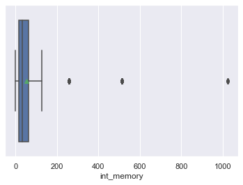

```python
sns.boxplot(data=df2, x="int_memory", showmeans=True) # box_plot for int_memory
```

```python
df2.int_memory.describe()
```

```
count    3360.000000
mean       52.320640
std        84.699977
min         0.010000
25%        16.000000
50%        32.000000
75%        64.000000
max      1024.000000
Name: int_memory, dtype: float64
```

```python
df2[df2["int_memory"]>400].describe() # checking the values with >400 GM int_memory
```

|  | screen_size | main_camera_mp | selfie_camera_mp | int_memory | ram | battery | weight | release_year | days_used | new_price | used_price | used_price_log | new_price_log |
| --- | --- | --- | --- | --- | --- | --- | --- | --- | --- | --- | --- | --- | --- |
| count | 52.000000 | 52.000000 | 52.000000 | 52.000000 | 52.000000 | 52.000000 | 52.000000 | 52.000000 | 52.000000 | 52.000000 | 52.000000 | 52.000000 | 52.000000 |
| mean | 11.730192 | 5.571154 | 3.836538 | 590.769231 | 2.461538 | 2493.019231 | 168.436538 | 2014.826923 | 724.192308 | 477.095385 | 129.759423 | 3.945794 | 4.989158 |
| std | 5.426063 | 4.440625 | 5.752477 | 186.532509 | 3.472365 | 1713.749959 | 94.915752 | 2.502713 | 232.184430 | 765.531183 | 183.753777 | 1.307017 | 1.453167 |
| min | 5.280000 | 1.300000 | 0.300000 | 512.000000 | 0.250000 | 1000.000000 | 98.000000 | 2013.000000 | 129.000000 | 39.580000 | 14.300000 | 2.660260 | 3.678324 |
| 25% | 7.750000 | 2.000000 | 0.300000 | 512.000000 | 0.250000 | 1400.000000 | 118.000000 | 2013.000000 | 571.500000 | 50.077500 | 20.632500 | 3.026863 | 3.913572 |
| 50% | 10.160000 | 3.150000 | 0.300000 | 512.000000 | 0.250000 | 1612.500000 | 137.000000 | 2013.500000 | 778.500000 | 69.790000 | 24.405000 | 3.194729 | 4.245484 |
| 75% | 15.340000 | 10.875000 | 7.000000 | 512.000000 | 4.000000 | 3362.500000 | 177.750000 | 2018.000000 | 915.000000 | 487.577500 | 248.185000 | 5.513644 | 6.149104 |
| max | 30.710000 | 13.000000 | 20.000000 | 1024.000000 | 12.000000 | 9720.000000 | 631.000000 | 2020.000000 | 1056.000000 | 2560.200000 | 749.520000 | 6.619433 | 7.847841 |

```python
df2[df2["int_memory"]>400].sample(n=10)
```

|  | brand_name | os | screen_size | 4g | 5g | main_camera_mp | selfie_camera_mp | int_memory | ram | battery | weight | release_year | days_used | new_price | used_price | used_price_log | new_price_log | device_category |
| --- | --- | --- | --- | --- | --- | --- | --- | --- | --- | --- | --- | --- | --- | --- | --- | --- | --- | --- |
| 2251 | Others | Android | 12.70 | no | no | 5.00 | 0.3 | 1024.0 | 4.00 | 2200.0 | 170.0 | 2013 | 584 | 170.00 | 58.61 | 4.070905 | 5.135798 | Budget |
| 1631 | Lenovo | Android | 10.16 | no | no | 3.15 | 1.0 | 512.0 | 0.25 | 1500.0 | 134.0 | 2013 | 836 | 90.49 | 35.01 | 3.555634 | 4.505239 | Budget |
| 2761 | Spice | Android | 10.16 | no | no | 3.15 | 1.3 | 512.0 | 0.25 | 2100.0 | 158.0 | 2013 | 1025 | 49.53 | 20.52 | 3.021400 | 3.902579 | Budget |
| 1466 | Lava | Android | 7.75 | no | no | 2.00 | 0.3 | 512.0 | 0.25 | 1400.0 | 115.4 | 2013 | 912 | 41.54 | 17.16 | 2.842581 | 3.726657 | Budget |
| 1912 | Micromax | Android | 10.16 | no | no | 2.00 | 0.3 | 512.0 | 0.25 | 1500.0 | 118.0 | 2013 | 1015 | 60.19 | 24.67 | 3.205588 | 4.097506 | Budget |
| 1467 | Lava | Android | 7.75 | no | no | 2.00 | 0.3 | 512.0 | 0.25 | 1400.0 | 115.4 | 2013 | 924 | 41.58 | 15.42 | 2.735665 | 3.727619 | Budget |
| 1490 | Lenovo | Android | 16.23 | yes | no | 13.00 | 8.0 | 512.0 | 4.00 | 3350.0 | 210.0 | 2018 | 660 | 400.44 | 176.66 | 5.174227 | 5.992564 | Premium |
| 1426 | Karbonn | Android | 7.85 | no | no | 5.00 | 0.3 | 512.0 | 0.25 | 1625.0 | 114.5 | 2013 | 992 | 71.90 | 24.14 | 3.183870 | 4.275276 | Budget |
| 263 | Huawei | Android | 16.59 | yes | yes | 13.00 | 16.0 | 512.0 | 12.00 | 4500.0 | 198.0 | 2019 | 488 | 1701.54 | 401.80 | 5.995954 | 7.439289 | Premium |
| 2325 | Others | Android | 10.08 | no | no | 3.15 | 0.3 | 512.0 | 0.25 | 2100.0 | 150.0 | 2014 | 818 | 61.29 | 22.21 | 3.100543 | 4.115617 | Budget |

## Observations:

Not treating this outliers, as this looks like the actual value after some research on the internet.

## 5. Outlier Check on ram

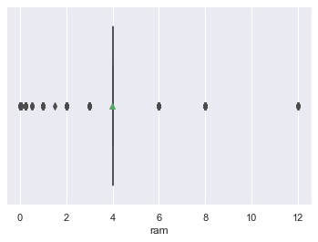

```python
sns.boxplot(data=df2, x="ram", showmeans=True) # box_plot for "ram"
```

```python
quartiles = np.quantile(df2['ram'][df2['ram'].notnull()], [.25, .75]) # specifying 1st and 3rd quartile limits
ram_4iqr = 4 * (quartiles[1] - quartiles[0])
print(f'Q1 = {quartiles[0]}, Q3 = {quartiles[1]}, 4*IQR = {ram_4iqr}') # getting the values outside 4 times of IQR
outlier_quartiles = df2.loc[np.abs(df2['ram'] - df2['ram'].median()) > ram_4iqr, 'ram'] # printing those values
outlier_quartiles
```

```
Q1 = 4.0, Q3 = 4.0, 4*IQR = 0.0
```

```
0       3.0
1       8.0
2       8.0
3       6.0
4       3.0
       ...
3449    6.0
3450    8.0
3451    3.0
3452    2.0
3453    2.0
Name: ram, Length: 562, dtype: float64
```

## 6. Outlier Check on "battery"

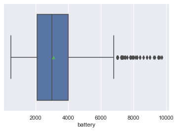

```python
sns.boxplot(data=df2, x="battery", showmeans=True) # plotting "battery" column
```

```python
df2[df2["battery"]>8000].describe() # checking the details of batteries with more than 8000 mAh
```

|  | screen_size | main_camera_mp | selfie_camera_mp | int_memory | ram | battery | weight | release_year | days_used | new_price | used_price | used_price_log | new_price_log |
| --- | --- | --- | --- | --- | --- | --- | --- | --- | --- | --- | --- | --- | --- |
| count | 27.000000 | 27.000000 | 27.000000 | 27.000000 | 27.000000 | 27.000000 | 27.000000 | 27.000000 | 27.000000 | 27.000000 | 27.000000 | 27.000000 | 27.000000 |
| mean | 26.315926 | 8.777778 | 3.533333 | 71.111111 | 3.888889 | 8919.555556 | 585.355556 | 2015.629630 | 743.703704 | 426.467778 | 173.574444 | 5.103017 | 5.943265 |
| std | 3.725280 | 2.577019 | 2.464517 | 192.631440 | 0.697982 | 561.368132 | 147.969564 | 2.168802 | 242.825961 | 228.967032 | 63.082171 | 0.322139 | 0.465243 |
| min | 12.830000 | 5.000000 | 1.200000 | 16.000000 | 2.000000 | 8134.000000 | 130.400000 | 2013.000000 | 220.000000 | 179.170000 | 102.350000 | 4.628398 | 5.188335 |
| 25% | 25.430000 | 8.000000 | 2.000000 | 16.000000 | 4.000000 | 8390.000000 | 480.000000 | 2014.000000 | 602.500000 | 279.580000 | 133.025000 | 4.890266 | 5.630984 |
| 50% | 25.430000 | 8.000000 | 2.000000 | 32.000000 | 4.000000 | 9000.000000 | 615.000000 | 2015.000000 | 766.000000 | 349.700000 | 156.990000 | 5.056182 | 5.857076 |
| 75% | 30.530000 | 8.000000 | 5.000000 | 32.000000 | 4.000000 | 9500.000000 | 692.600000 | 2017.500000 | 923.000000 | 484.365000 | 196.860000 | 5.282458 | 6.182347 |
| max | 30.710000 | 16.000000 | 8.000000 | 1024.000000 | 6.000000 | 9720.000000 | 855.000000 | 2020.000000 | 1089.000000 | 1100.860000 | 346.330000 | 5.847392 | 7.003847 |

```python
df2[df2["battery"]>8000].sample(n=10)
```

|  | brand_name | os | screen_size | 4g | 5g | main_camera_mp | selfie_camera_mp | int_memory | ram | battery | weight | release_year | days_used | new_price | used_price | used_price_log | new_price_log | device_category |
| --- | --- | --- | --- | --- | --- | --- | --- | --- | --- | --- | --- | --- | --- | --- | --- | --- | --- | --- |
| 2583 | Samsung | Android | 30.53 | no | no | 8.0 | 2.0 | 32.0 | 4.0 | 9500.0 | 750.0 | 2014 | 689 | 538.78 | 195.22 | 5.274127 | 6.289307 | Premium |
| 83 | LG | Android | 25.43 | yes | no | 8.0 | 5.0 | 32.0 | 4.0 | 8200.0 | 498.0 | 2019 | 329 | 340.20 | 111.01 | 4.709620 | 5.829534 | Mid_ranger |
| 2587 | Samsung | Android | 25.43 | yes | no | 8.0 | 2.0 | 16.0 | 4.0 | 8220.0 | 477.0 | 2014 | 925 | 418.59 | 166.34 | 5.114034 | 6.036892 | Premium |
| 668 | Apple | iOS | 23.04 | yes | no | 5.0 | 1.2 | 16.0 | 4.0 | 8600.0 | 469.0 | 2013 | 995 | 349.70 | 102.35 | 4.628398 | 5.857076 | Mid_ranger |
| 2937 | Xiaomi | Android | 25.43 | yes | no | 13.0 | 5.0 | 128.0 | 4.0 | 8620.0 | 485.0 | 2018 | 665 | 260.62 | 166.71 | 5.116256 | 5.563063 | Mid_ranger |
| 654 | Apple | iOS | 25.53 | yes | no | 12.0 | 7.0 | 64.0 | 4.0 | 8134.0 | 469.0 | 2017 | 629 | 730.75 | 198.50 | 5.290789 | 6.594071 | Premium |
| 1602 | Lenovo | Android | 25.43 | no | no | 8.0 | 1.6 | 16.0 | 4.0 | 9000.0 | 615.0 | 2014 | 954 | 259.97 | 124.52 | 4.824466 | 5.560566 | Mid_ranger |
| 2581 | Samsung | Android | 30.53 | yes | no | 8.0 | 2.0 | 32.0 | 4.0 | 9500.0 | 753.0 | 2014 | 1089 | 669.49 | 285.01 | 5.652524 | 6.506516 | Premium |
| 75 | Lenovo | Android | 25.43 | yes | no | 8.0 | 8.0 | 16.0 | 2.0 | 8400.0 | 655.0 | 2016 | 691 | 179.69 | 156.99 | 5.056182 | 5.191233 | Budget |
| 644 | Apple | iOS | 30.71 | yes | no | 12.0 | 7.0 | 1024.0 | 4.0 | 9720.0 | 631.0 | 2018 | 543 | 1100.86 | 332.96 | 5.808022 | 7.003847 | Premium |

### Observations:

- Not treating these outliers in battery, as it looks like the valid ones matchingh "weight" and "screensize" feature.

## 7. Outlier Check on "weight"

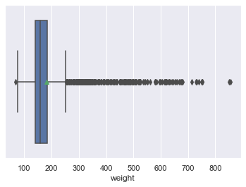

```python
sns.boxplot(data=df2, x="weight", showmeans=True) # box_plot for "weight" column
```

```python
df2[df2["weight"]>700] # checking the details of devices weighs >700 grams
```

|  | brand_name | os | screen_size | 4g | 5g | main_camera_mp | selfie_camera_mp | int_memory | ram | battery | weight | release_year | days_used | new_price | used_price | used_price_log | new_price_log | device_category |
| --- | --- | --- | --- | --- | --- | --- | --- | --- | --- | --- | --- | --- | --- | --- | --- | --- | --- | --- |
| 662 | Apple | iOS | 30.71 | yes | no | 8.0 | 1.2 | 32.0 | 4.0 | 3937.0 | 713.0 | 2015 | 572 | 849.52 | 259.53 | 5.558872 | 6.744671 | Premium |
| 1141 | Others | Android | 30.56 | no | no | 8.0 | 2.0 | 32.0 | 4.0 | 2500.0 | 850.0 | 2015 | 652 | 490.18 | 188.54 | 5.239310 | 6.194773 | Premium |
| 1142 | Others | Android | 25.43 | no | no | 5.0 | 2.0 | 16.0 | 4.0 | 8380.0 | 855.0 | 2015 | 889 | 239.91 | 174.79 | 5.163585 | 5.480264 | Mid_ranger |
| 2581 | Samsung | Android | 30.53 | yes | no | 8.0 | 2.0 | 32.0 | 4.0 | 9500.0 | 753.0 | 2014 | 1089 | 669.49 | 285.01 | 5.652524 | 6.506516 | Premium |
| 2582 | Samsung | Android | 30.53 | no | no | 8.0 | 2.0 | 32.0 | 4.0 | 9500.0 | 753.0 | 2014 | 1078 | 641.13 | 215.69 | 5.373842 | 6.463232 | Premium |
| 2583 | Samsung | Android | 30.53 | no | no | 8.0 | 2.0 | 32.0 | 4.0 | 9500.0 | 750.0 | 2014 | 689 | 538.78 | 195.22 | 5.274127 | 6.289307 | Premium |
| 2584 | Samsung | Android | 30.53 | yes | no | 8.0 | 2.0 | 32.0 | 4.0 | 9500.0 | 740.0 | 2014 | 921 | 499.55 | 207.86 | 5.336865 | 6.213708 | Premium |
| 2585 | Samsung | Android | 30.53 | no | no | 8.0 | 2.0 | 32.0 | 4.0 | 9500.0 | 732.0 | 2014 | 799 | 469.18 | 205.79 | 5.326856 | 6.150986 | Premium |
| 2586 | Samsung | Android | 30.53 | no | no | 8.0 | 2.0 | 32.0 | 4.0 | 9500.0 | 730.2 | 2014 | 1061 | 420.94 | 139.84 | 4.940499 | 6.042490 | Premium |

## Observations:

Not treating these outliers as it looks like the valid values comparing to "screen_size" and "battery"

## 8. Outlier Check on "days_used"

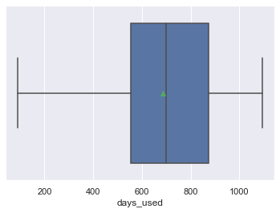

```python
sns.boxplot(data=df2, x="days_used", showmeans=True) # box_plot for days_used
```

### Observation:

There is no outlier in this feature.

## 9. Outlier Checks on "new_price"

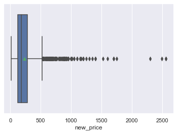

```python
sns.boxplot(data=df2, x="new_price", showmeans=True) # box_plot for "new_price"
```

```python
df2[df2["new_price"]>2000] # checking the devices values >2000
```

|  | brand_name | os | screen_size | 4g | 5g | main_camera_mp | selfie_camera_mp | int_memory | ram | battery | weight | release_year | days_used | new_price | used_price | used_price_log | new_price_log | device_category |
| --- | --- | --- | --- | --- | --- | --- | --- | --- | --- | --- | --- | --- | --- | --- | --- | --- | --- | --- |
| 198 | Xiaomi | Android | 20.12 | yes | yes | 12.0 | 20.0 | 512.0 | 12.0 | 4050.0 | 241.0 | 2019 | 478 | 2498.24 | 749.52 | 6.619433 | 7.823342 | Premium |
| 1262 | Huawei | Android | 20.32 | yes | no | 13.0 | 16.0 | 512.0 | 4.0 | 4500.0 | 295.0 | 2019 | 434 | 2300.87 | 360.61 | 5.887797 | 7.741043 | Premium |
| 3207 | Huawei | Android | 20.32 | yes | yes | 10.5 | 16.0 | 512.0 | 8.0 | 4500.0 | 300.0 | 2020 | 248 | 2560.20 | 665.44 | 6.500448 | 7.847841 | Premium |
| 3348 | Huawei | Android | 20.32 | yes | yes | 10.5 | 16.0 | 512.0 | 8.0 | 4500.0 | 300.0 | 2020 | 129 | 2560.20 | 387.32 | 5.959251 | 7.847841 | Premium |

### Observations:

Not these outliers as it looks valid based on the release year.

## 10. Outlier Checks on "used_price"

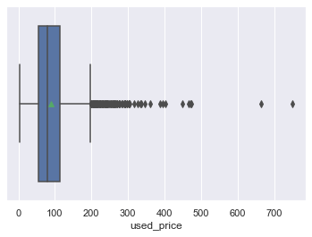

```python
sns.boxplot(data=df2, x="used_price", showmeans=True) # Box_plot for used_price
```

```python
df2[df2["used_price"]>600] # fetching the details of devices >600 Euros
```

|  | brand_name | os | screen_size | 4g | 5g | main_camera_mp | selfie_camera_mp | int_memory | ram | battery | weight | release_year | days_used | new_price | used_price | used_price_log | new_price_log | device_category |
| --- | --- | --- | --- | --- | --- | --- | --- | --- | --- | --- | --- | --- | --- | --- | --- | --- | --- | --- |
| 198 | Xiaomi | Android | 20.12 | yes | yes | 12.0 | 20.0 | 512.0 | 12.0 | 4050.0 | 241.0 | 2019 | 478 | 2498.24 | 749.52 | 6.619433 | 7.823342 | Premium |
| 3207 | Huawei | Android | 20.32 | yes | yes | 10.5 | 16.0 | 512.0 | 8.0 | 4500.0 | 300.0 | 2020 | 248 | 2560.20 | 665.44 | 6.500448 | 7.847841 | Premium |

### Observations:

Not treating these outliers as these values looks valid based on the release year and other features.

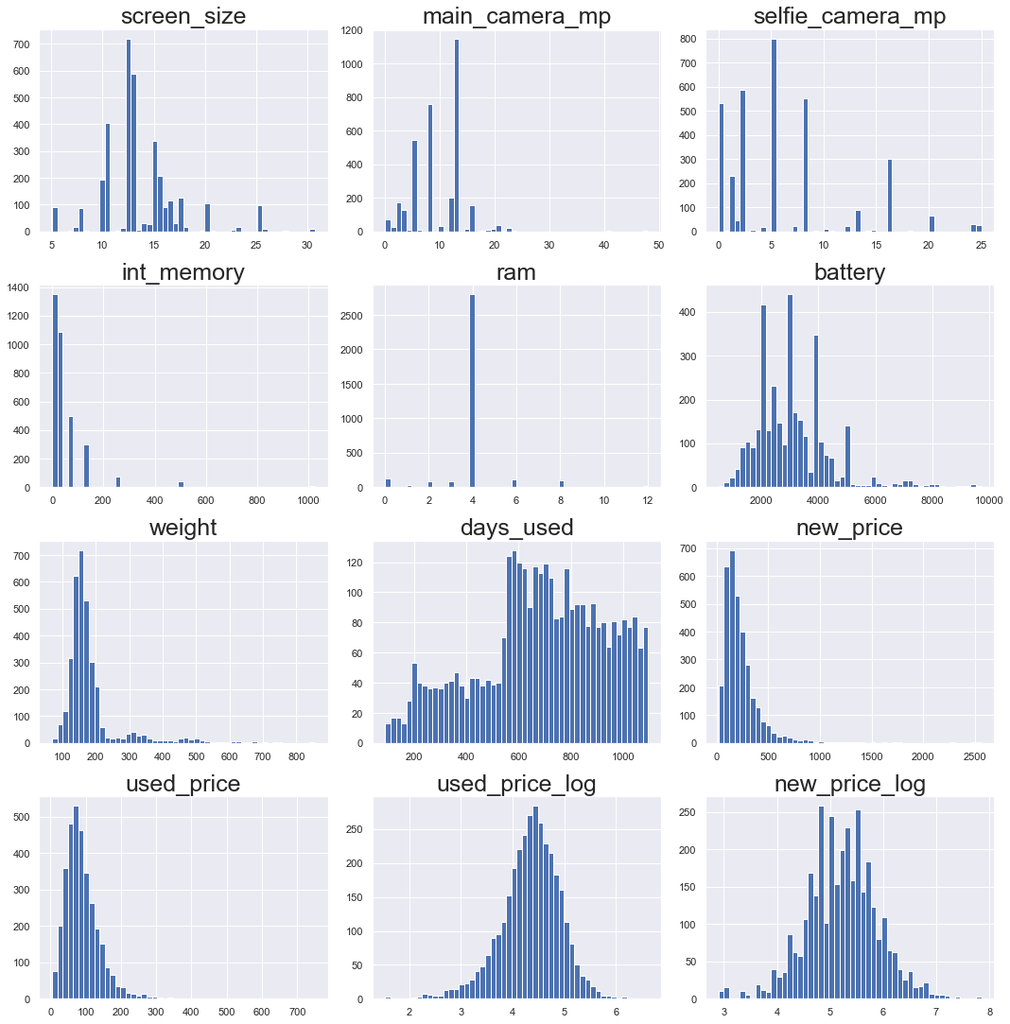

```python
# Checking the distrinbution of all numeric columns using histplot.

plt.figure(figsize=(15, 45))

for i in range(len(numeric_columns)):
    plt.subplot(12, 3, i + 1)
    plt.hist(df2[numeric_columns[i]], bins=50)
    plt.tight_layout()
    plt.title(numeric_columns[i], fontsize=25)

plt.show()
```

### Observation:

- "Weight" and internal memory is right skewed. Apllying log might help is skewness rectification.

```python
df2["weight_log"]=np.log(df2["weight"]) # applying log to "weight"
```

```python
df2["int_memory"]=np.log(df2["int_memory"]) # applying  log to "int-memory"
```

```python
df2["int_memory"]=df1["int_memory"] # As the log of "int_memory" gave some negative values, changed it back to its actual value with log.
```

```python
df2.drop("new_price", axis=1, inplace=True) # drop new price
```

```python
df2.drop("weight", axis=1, inplace=True) # drop weight
```

```python
numeric_columns2 = df2.select_dtypes(include=np.number).columns.tolist() # get new numeric variables afte dropping all other actual variables
```

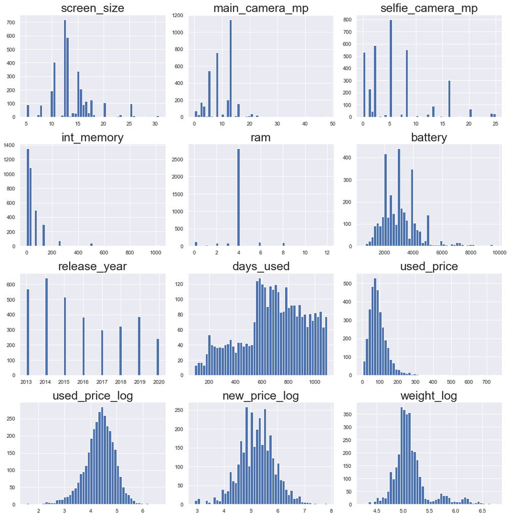

```python
plt.figure(figsize=(15, 45))

for i in range(len(numeric_columns2)):
    plt.subplot(12, 3, i + 1)
    plt.hist(df2[numeric_columns2[i]], bins=50)
    plt.tight_layout()
    plt.title(numeric_columns2[i], fontsize=25)

plt.show()  # check the distribution now.
```

### Observtion:

# Data Preparation

```python
df3=df2.copy()
```

```python
df3.columns
```

```
Index(['brand_name', 'os', 'screen_size', '4g', '5g', 'main_camera_mp',
       'selfie_camera_mp', 'int_memory', 'ram', 'battery', 'release_year',
       'days_used', 'used_price', 'used_price_log', 'new_price_log',
       'device_category', 'weight_log'],
      dtype='object')
```

```python
df3[df3.isna().any(axis=1)]
```

|  | brand_name | os | screen_size | 4g | 5g | main_camera_mp | selfie_camera_mp | int_memory | ram | battery | release_year | days_used | used_price | used_price_log | new_price_log | device_category | weight_log |
| --- | --- | --- | --- | --- | --- | --- | --- | --- | --- | --- | --- | --- | --- | --- | --- | --- | --- |

```python
df3["weight_log"] = df3["weight_log"].fillna(df3["weight_log"].median())
```

```python
# defining the dependent and independent variables
X = df3.drop(["used_price_log", "device_category"], axis=1)##  drop used_price_log", "device_category" from the data
y = df3["used_price_log"]

print(X.sample(n=5))
print()
print(y.sample(n=5))
```

```
     brand_name       os  screen_size   4g  5g  main_camera_mp  \
181        Vivo  Android        16.13  yes  no            13.0
1406     Huawei  Android        15.27   no  no             8.0
552     Alcatel  Android        10.16   no  no             5.0
3049       XOLO  Android        10.29   no  no             8.0
887      Others  Android        12.70   no  no             5.0

      selfie_camera_mp  int_memory  ram  battery  release_year  days_used  \
181               20.0       128.0  4.0   5000.0          2019        334
1406               1.0        32.0  4.0   4050.0          2013        949
552                0.3        16.0  4.0   1300.0          2013        764
3049               1.0        16.0  4.0   2100.0          2013        571
887                0.3        16.0  4.0   2000.0          2013        816

      used_price  new_price_log  weight_log
181       116.96       5.440511    5.249652
1406       98.64       5.444709    5.288267
552        35.07       4.379774    4.700480
3049       43.79       4.869916    4.966335
887        35.00       4.615813    4.852030

1933    3.742894
315     3.131137
2950    4.384149
2088    4.502916
1714    4.115617
Name: used_price_log, dtype: float64
```

```python
# creating dummy variables
X = pd.get_dummies(
    X,
    columns=X.select_dtypes(include=["object", "category"]).columns.tolist(),
    drop_first=True,
)  ## create dummies for independent features

X.head()
```

|  | screen_size | main_camera_mp | selfie_camera_mp | int_memory | ram | battery | release_year | days_used | used_price | new_price_log | weight_log | brand_name_Alcatel | brand_name_Apple | brand_name_Asus | brand_name_BlackBerry | brand_name_Celkon | brand_name_Coolpad | brand_name_Gionee | brand_name_Google | brand_name_HTC | brand_name_Honor | brand_name_Huawei | brand_name_Infinix | brand_name_Karbonn | brand_name_LG | brand_name_Lava | brand_name_Lenovo | brand_name_Meizu | brand_name_Micromax | … |
| --- | --- | --- | --- | --- | --- | --- | --- | --- | --- | --- | --- | --- | --- | --- | --- | --- | --- | --- | --- | --- | --- | --- | --- | --- | --- | --- | --- | --- | --- | --- |
| 0 | 14.50 | 13.0 | 5.0 | 64.0 | 3.0 | 3020.0 | 2020 | 127 | 74.26 | 4.715100 | 4.983607 | 0 | 0 | 0 | 0 | 0 | 0 | 0 | 0 | 0 | 1 | 0 | 0 | 0 | 0 | 0 | 0 | 0 | 0 | … |
| 1 | 17.30 | 13.0 | 16.0 | 128.0 | 8.0 | 4300.0 | 2020 | 325 | 174.53 | 5.519018 | 5.361292 | 0 | 0 | 0 | 0 | 0 | 0 | 0 | 0 | 0 | 1 | 0 | 0 | 0 | 0 | 0 | 0 | 0 | 0 | … |
| 2 | 16.69 | 13.0 | 8.0 | 128.0 | 8.0 | 4200.0 | 2020 | 162 | 165.85 | 5.884631 | 5.361292 | 0 | 0 | 0 | 0 | 0 | 0 | 0 | 0 | 0 | 1 | 0 | 0 | 0 | 0 | 0 | 0 | 0 | 0 | … |
| 3 | 25.50 | 13.0 | 8.0 | 64.0 | 6.0 | 7250.0 | 2020 | 345 | 169.93 | 5.630961 | 6.173786 | 0 | 0 | 0 | 0 | 0 | 0 | 0 | 0 | 0 | 1 | 0 | 0 | 0 | 0 | 0 | 0 | 0 | 0 | … |
| 4 | 15.32 | 13.0 | 8.0 | 64.0 | 3.0 | 5000.0 | 2020 | 293 | 80.64 | 4.947837 | 5.220356 | 0 | 0 | 0 | 0 | 0 | 0 | 0 | 0 | 0 | 1 | 0 | 0 | 0 | 0 | 0 | 0 | 0 | 0 | … |

```python
df3.shape
```

```
(3360, 17)
```

### Onservations:

```python
# splitting the data in 70:30 ratio for train to test data

x_train, x_test, y_train, y_test =train_test_split(
    X, y, test_size=0.30, random_state=1
)
```

```python
print("Number of rows in train data =", x_train.shape[0])
print("Number of rows in test data =", x_test.shape[0])
```

```
Number of rows in train data = 2352
Number of rows in test data = 1008
```

# Linear Regression using stats model

- Let's build a linear regression model using statsmodels.

```python
# adding constant to the train data
x_train1 = sm.add_constant(x_train)
# adding constant to the test data
x_test1 = sm.add_constant(x_test)
```

```python
olsmodel1 = sm.OLS(y_train, x_train1)
olsres = olsmodel1.fit()
print(olsres.summary())
```

```
                            OLS Regression Results
==============================================================================
Dep. Variable:         used_price_log   R-squared:                       0.909
Model:                            OLS   Adj. R-squared:                  0.907
Method:                 Least Squares   F-statistic:                     470.7
Date:                Sat, 11 Dec 2021   Prob (F-statistic):               0.00
Time:                        08:11:05   Log-Likelihood:                 796.49
No. Observations:                2352   AIC:                            -1493.
Df Residuals:                    2302   BIC:                            -1205.
Df Model:                          49
Covariance Type:            nonrobust
=========================================================================================
                            coef    std err          t      P>|t|      [0.025      0.975]
-----------------------------------------------------------------------------------------
const                   -18.2206      7.061     -2.581      0.010     -32.067      -4.374
screen_size               0.0141      0.002      5.854      0.000       0.009       0.019
main_camera_mp            0.0144      0.001     12.518      0.000       0.012       0.017
selfie_camera_mp          0.0071      0.001      6.279      0.000       0.005       0.009
int_memory               -0.0005   5.02e-05    -10.756      0.000      -0.001      -0.000
ram                       0.0084      0.004      2.052      0.040       0.000       0.016
battery               -9.315e-06   5.58e-06     -1.670      0.095   -2.03e-05    1.62e-06
release_year              0.0099      0.003      2.839      0.005       0.003       0.017
days_used              2.496e-05   2.28e-05      1.094      0.274   -1.98e-05    6.97e-05
used_price                0.0058      0.000     43.173      0.000       0.006       0.006
new_price_log             0.1855      0.011     17.210      0.000       0.164       0.207
weight_log                0.1409      0.024      5.771      0.000       0.093       0.189
brand_name_Alcatel       -0.0365      0.034     -1.063      0.288      -0.104       0.031
brand_name_Apple         -0.2240      0.132     -1.703      0.089      -0.482       0.034
brand_name_Asus           0.0168      0.034      0.487      0.626      -0.051       0.084
brand_name_BlackBerry     0.1450      0.058      2.520      0.012       0.032       0.258
brand_name_Celkon        -0.2182      0.050     -4.335      0.000      -0.317      -0.120
brand_name_Coolpad        0.0292      0.051      0.576      0.565      -0.070       0.128
brand_name_Gionee        -0.0347      0.042     -0.831      0.406      -0.117       0.047
brand_name_Google        -0.0217      0.063     -0.344      0.731      -0.145       0.102
brand_name_HTC           -0.0166      0.035     -0.470      0.638      -0.086       0.053
brand_name_Honor          0.0365      0.036      1.017      0.309      -0.034       0.107
brand_name_Huawei        -0.0439      0.032     -1.357      0.175      -0.107       0.020
brand_name_Infinix        0.1162      0.078      1.489      0.137      -0.037       0.269
brand_name_Karbonn       -0.0895      0.052     -1.730      0.084      -0.191       0.012
brand_name_LG            -0.0200      0.033     -0.611      0.541      -0.084       0.044
```

[output cut: 20 more lines]

```
os_Windows               -0.0199      0.032     -0.615      0.539      -0.084       0.044
os_iOS                    0.0754      0.132      0.570      0.568      -0.184       0.334
4g_yes                    0.0475      0.012      3.991      0.000       0.024       0.071
5g_yes                   -0.1538      0.026     -5.876      0.000      -0.205      -0.102
==============================================================================
Omnibus:                     1353.868   Durbin-Watson:                   1.994
Prob(Omnibus):                  0.000   Jarque-Bera (JB):            39226.856
Skew:                          -2.180   Prob(JB):                         0.00
Kurtosis:                      22.526   Cond. No.                     7.74e+06
==============================================================================

Notes:
[1] Standard Errors assume that the covariance matrix of the errors is correctly specified.
[2] The condition number is large, 7.74e+06. This might indicate that there are
strong multicollinearity or other numerical problems.
```

## Checking Linear Regression Assumptions

We will be checking the following Linear Regression assumptions:

1. **No Multicollinearity**
2. **Linearity of variables**
3. **Independence of error terms**
4. **Normality of error terms**
5. **No Heteroscedasticity**

### 1. TEST FOR MULTICOLLINEARITY

- We will test for multicollinearity using VIF.
- There are different ways of detecting (or testing) multicollinearity. One such way is Variation Inflation Factor.
- **Variance Inflation factor**: Variance inflation factors measure the inflation in the variances of the regression coefficients estimates due to collinearities that exist among the predictors. It is a measure of how much the variance of the estimated regression coefficient $\beta_k$ is "inflated" by the existence of correlation among the predictor variables in the model.
- **General Rule of Thumb**:
  - If VIF is 1, then there is no correlation among the $k$th predictor and the remaining predictor variables, and hence, the variance of $\beta_k$ is not inflated at all.
  - If VIF exceeds 5, we say there is moderate VIF, and if it is 10 or exceeding 10, it shows signs of high multi-collinearity.
  - The purpose of the analysis should dictate which threshold to use.

```python
from statsmodels.stats.outliers_influence import variance_inflation_factor

# we will define a function to check VIF
def checking_vif(predictors):
    vif = pd.DataFrame()
    vif["feature"] = predictors.columns

    # calculating VIF for each feature
    vif["VIF"] = [
        variance_inflation_factor(predictors.values, i)
        for i in range(len(predictors.columns))
    ]
    return vif
```

```python
checking_vif(x_train1) # checking VIF on train1
```

|  | feature | VIF |
| --- | --- | --- |
| 0 | const | 3.858658e+06 |
| 1 | screen_size | 6.794422e+00 |
| 2 | main_camera_mp | 2.311828e+00 |
| 3 | selfie_camera_mp | 3.122843e+00 |
| 4 | int_memory | 1.410621e+00 |
| 5 | ram | 2.130495e+00 |
| 6 | battery | 4.217850e+00 |
| 7 | release_year | 4.792988e+00 |
| 8 | days_used | 2.409210e+00 |
| 9 | used_price | 3.979995e+00 |
| 10 | new_price_log | 4.069081e+00 |
| 11 | weight_log | 5.637930e+00 |
| 12 | brand_name_Alcatel | 3.327112e+00 |
| 13 | brand_name_Apple | 1.518956e+01 |
| 14 | brand_name_Asus | 3.307439e+00 |
| 15 | brand_name_BlackBerry | 1.408389e+00 |
| 16 | brand_name_Celkon | 1.653012e+00 |
| 17 | brand_name_Coolpad | 1.508267e+00 |
| 18 | brand_name_Gionee | 1.923990e+00 |
| 19 | brand_name_Google | 1.302638e+00 |
| 20 | brand_name_HTC | 3.058622e+00 |
| 21 | brand_name_Honor | 3.077646e+00 |
| 22 | brand_name_Huawei | 5.215882e+00 |
| 23 | brand_name_Infinix | 1.200328e+00 |
| 24 | brand_name_Karbonn | 1.484291e+00 |
| 25 | brand_name_LG | 4.550896e+00 |
| 26 | brand_name_Lava | 1.622523e+00 |
| 27 | brand_name_Lenovo | 4.224090e+00 |
| 28 | brand_name_Meizu | 2.212539e+00 |
| 29 | brand_name_Micromax | 2.977213e+00 |
| 30 | brand_name_Microsoft | 1.577630e+00 |
| 31 | brand_name_Motorola | 3.152279e+00 |
| 32 | brand_name_Nokia | 2.971692e+00 |
| 33 | brand_name_OnePlus | 1.533454e+00 |
| 34 | brand_name_Oppo | 3.321264e+00 |
| 35 | brand_name_Others | 8.847508e+00 |
| 36 | brand_name_Panasonic | 1.970948e+00 |
| 37 | brand_name_Realme | 1.885178e+00 |
| 38 | brand_name_Samsung | 6.913939e+00 |
| 39 | brand_name_Sony | 2.848895e+00 |
| 40 | brand_name_Spice | 1.614288e+00 |
| 41 | brand_name_Vivo | 3.194980e+00 |
| 42 | brand_name_XOLO | 1.815480e+00 |
| 43 | brand_name_Xiaomi | 3.530006e+00 |
| 44 | brand_name_ZTE | 3.280361e+00 |
| 45 | os_Others | 1.603470e+00 |
| 46 | os_Windows | 1.493129e+00 |
| 47 | os_iOS | 1.420675e+01 |
| 48 | 4g_yes | 2.412712e+00 |
| 49 | 5g_yes | 1.784457e+00 |

# Observation:

```python
def treating_multicollinearity(predictors, target, high_vif_columns):
    """
    Checking the effect of dropping the columns showing high multicollinearity
    on model performance (adj. R-squared and RMSE)

    predictors: independent variables
    target: dependent variable
    high_vif_columns: columns having high VIF
    """
    # empty lists to store adj. R-squared and RMSE values
    adj_r2 = []
    rmse = []

    # build ols models by dropping one of the high VIF columns at a time
    # store the adjusted R-squared and RMSE in the lists defined previously
    for cols in high_vif_columns:
        # defining the new train set
        train = predictors.loc[:, ~predictors.columns.str.startswith(cols)]

        # create the model
        olsmodel = sm.OLS(target, train).fit()

        # adding adj. R-squared and RMSE to the lists
        adj_r2.append(olsmodel.rsquared_adj)
        rmse.append(np.sqrt(olsmodel.mse_resid))

    # creating a dataframe for the results
    temp = pd.DataFrame(
        {
            "col": high_vif_columns,
            "Adj. R-squared after_dropping col": adj_r2,
            "RMSE after dropping col": rmse,
        }
    ).sort_values(by="Adj. R-squared after_dropping col", ascending=False)
    temp.reset_index(drop=True, inplace=True)

    return temp
```

```python
col_list = [
    "screen_size",
    "weight_log",
    "brand_name_Huawei",
    "brand_name_Others",
    "brand_name_Samsung",
    "brand_name_apple",
    "os_ios"
]

res = treating_multicollinearity(x_train1, y_train, col_list)
res
```

|  | col | Adj. R-squared after_dropping col | RMSE after dropping col |
| --- | --- | --- | --- |
| 0 | brand_name_Samsung | 0.907326 | 0.174313 |
| 1 | brand_name_Others | 0.907319 | 0.174320 |
| 2 | brand_name_apple | 0.907314 | 0.174324 |
| 3 | os_ios | 0.907314 | 0.174324 |
| 4 | brand_name_Huawei | 0.907280 | 0.174356 |
| 5 | weight_log | 0.906014 | 0.175543 |
| 6 | screen_size | 0.905975 | 0.175579 |

```python
# dropping "brand_name_Samsung" and check of VIF again.
col_to_drop = "brand_name_Samsung"
x_train2 = x_train1.loc[:, ~x_train1.columns.str.startswith(col_to_drop)]
x_test2 = x_test1.loc[:, ~x_test1.columns.str.startswith(col_to_drop)]

# Check VIF now
vif = checking_vif(x_train2)
print("VIF after dropping ", col_to_drop)
vif
```

```
VIF after dropping  brand_name_Samsung
```

|  | feature | VIF |
| --- | --- | --- |
| 0 | const | 3.858595e+06 |
| 1 | screen_size | 6.786291e+00 |
| 2 | main_camera_mp | 2.309884e+00 |
| 3 | selfie_camera_mp | 3.122078e+00 |
| 4 | int_memory | 1.410489e+00 |
| 5 | ram | 2.130339e+00 |
| 6 | battery | 4.215294e+00 |
| 7 | release_year | 4.792719e+00 |
| 8 | days_used | 2.409208e+00 |
| 9 | used_price | 3.979747e+00 |
| 10 | new_price_log | 4.057440e+00 |
| 11 | weight_log | 5.637918e+00 |
| 12 | brand_name_Alcatel | 1.328026e+00 |
| 13 | brand_name_Apple | 1.447011e+01 |
| 14 | brand_name_Asus | 1.284060e+00 |
| 15 | brand_name_BlackBerry | 1.085073e+00 |
| 16 | brand_name_Celkon | 1.205987e+00 |
| 17 | brand_name_Coolpad | 1.074267e+00 |
| 18 | brand_name_Gionee | 1.126220e+00 |
| 19 | brand_name_Google | 1.053216e+00 |
| 20 | brand_name_HTC | 1.270384e+00 |
| 21 | brand_name_Honor | 1.339676e+00 |
| 22 | brand_name_Huawei | 1.555009e+00 |
| 23 | brand_name_Infinix | 1.055754e+00 |
| 24 | brand_name_Karbonn | 1.110999e+00 |
| 25 | brand_name_LG | 1.437095e+00 |
| 26 | brand_name_Lava | 1.130901e+00 |
| 27 | brand_name_Lenovo | 1.424596e+00 |
| 28 | brand_name_Meizu | 1.186117e+00 |
| 29 | brand_name_Micromax | 1.339142e+00 |
| 30 | brand_name_Microsoft | 1.370434e+00 |
| 31 | brand_name_Motorola | 1.338597e+00 |
| 32 | brand_name_Nokia | 1.460234e+00 |
| 33 | brand_name_OnePlus | 1.114546e+00 |
| 34 | brand_name_Oppo | 1.350080e+00 |
| 35 | brand_name_Others | 2.034919e+00 |
| 36 | brand_name_Panasonic | 1.139326e+00 |
| 37 | brand_name_Realme | 1.199415e+00 |
| 38 | brand_name_Sony | 1.280207e+00 |
| 39 | brand_name_Spice | 1.132221e+00 |
| 40 | brand_name_Vivo | 1.361002e+00 |
| 41 | brand_name_XOLO | 1.160534e+00 |
| 42 | brand_name_Xiaomi | 1.419909e+00 |
| 43 | brand_name_ZTE | 1.308684e+00 |
| 44 | os_Others | 1.601953e+00 |
| 45 | os_Windows | 1.490772e+00 |
| 46 | os_iOS | 1.420622e+01 |
| 47 | 4g_yes | 2.394653e+00 |
| 48 | 5g_yes | 1.784179e+00 |

```python
# Check of R and Adjusted R values after dropping
col_list = [
    "screen_size",
    "weight_log",
    "brand_name_Huawei",
    "brand_name_Others",
    "brand_name_apple",
    "os_ios"
]

res = treating_multicollinearity(x_train2, y_train, col_list)
res
```

|  | col | Adj. R-squared after_dropping col | RMSE after dropping col |
| --- | --- | --- | --- |
| 0 | brand_name_Others | 0.907359 | 0.174282 |
| 1 | brand_name_apple | 0.907326 | 0.174313 |
| 2 | os_ios | 0.907326 | 0.174313 |
| 3 | brand_name_Huawei | 0.907308 | 0.174330 |
| 4 | weight_log | 0.906027 | 0.175530 |
| 5 | screen_size | 0.905972 | 0.175582 |

```python
# Drop of "brand_name_Apple" and check of VIF

col_to_drop = "brand_name_Apple"
x_train3 = x_train2.loc[:, ~x_train2.columns.str.startswith(col_to_drop)]
x_test3 = x_test2.loc[:, ~x_test2.columns.str.startswith(col_to_drop)]

# Check VIF now
vif = checking_vif(x_train3)
print("VIF after dropping ", col_to_drop)
vif
```

```
VIF after dropping  brand_name_Apple
```

|  | feature | VIF |
| --- | --- | --- |
| 0 | const | 3.854649e+06 |
| 1 | screen_size | 6.769019e+00 |
| 2 | main_camera_mp | 2.309854e+00 |
| 3 | selfie_camera_mp | 3.096345e+00 |
| 4 | int_memory | 1.409809e+00 |
| 5 | ram | 2.127963e+00 |
| 6 | battery | 4.196352e+00 |
| 7 | release_year | 4.787671e+00 |
| 8 | days_used | 2.408406e+00 |
| 9 | used_price | 3.966297e+00 |
| 10 | new_price_log | 4.055377e+00 |
| 11 | weight_log | 5.622457e+00 |
| 12 | brand_name_Alcatel | 1.327471e+00 |
| 13 | brand_name_Asus | 1.282734e+00 |
| 14 | brand_name_BlackBerry | 1.083317e+00 |
| 15 | brand_name_Celkon | 1.205983e+00 |
| 16 | brand_name_Coolpad | 1.074240e+00 |
| 17 | brand_name_Gionee | 1.126087e+00 |
| 18 | brand_name_Google | 1.052282e+00 |
| 19 | brand_name_HTC | 1.270315e+00 |
| 20 | brand_name_Honor | 1.338307e+00 |
| 21 | brand_name_Huawei | 1.552310e+00 |
| 22 | brand_name_Infinix | 1.055503e+00 |
| 23 | brand_name_Karbonn | 1.110797e+00 |
| 24 | brand_name_LG | 1.435740e+00 |
| 25 | brand_name_Lava | 1.130776e+00 |
| 26 | brand_name_Lenovo | 1.423009e+00 |
| 27 | brand_name_Meizu | 1.185885e+00 |
| 28 | brand_name_Micromax | 1.339140e+00 |
| 29 | brand_name_Microsoft | 1.370124e+00 |
| 30 | brand_name_Motorola | 1.338164e+00 |
| 31 | brand_name_Nokia | 1.456850e+00 |
| 32 | brand_name_OnePlus | 1.114170e+00 |
| 33 | brand_name_Oppo | 1.349650e+00 |
| 34 | brand_name_Others | 2.033140e+00 |
| 35 | brand_name_Panasonic | 1.139275e+00 |
| 36 | brand_name_Realme | 1.198745e+00 |
| 37 | brand_name_Sony | 1.279582e+00 |
| 38 | brand_name_Spice | 1.132026e+00 |
| 39 | brand_name_Vivo | 1.360059e+00 |
| 40 | brand_name_XOLO | 1.160534e+00 |
| 41 | brand_name_Xiaomi | 1.418576e+00 |
| 42 | brand_name_ZTE | 1.308381e+00 |
| 43 | os_Others | 1.543462e+00 |
| 44 | os_Windows | 1.489730e+00 |
| 45 | os_iOS | 1.147271e+00 |
| 46 | 4g_yes | 2.394567e+00 |
| 47 | 5g_yes | 1.777489e+00 |

```python
# check of R and Adjusted R.
col_list = [
    "screen_size",
    "weight_log",
    "brand_name_Huawei",
    "brand_name_Others",
       "os_ios"
]

res = treating_multicollinearity(x_train3, y_train, col_list)
res
```

|  | col | Adj. R-squared after_dropping col | RMSE after dropping col |
| --- | --- | --- | --- |
| 0 | brand_name_Others | 0.907303 | 0.174335 |
| 1 | os_ios | 0.907269 | 0.174367 |
| 2 | brand_name_Huawei | 0.907257 | 0.174378 |
| 3 | screen_size | 0.905949 | 0.175603 |
| 4 | weight_log | 0.905929 | 0.175623 |

```python
# drop of "os_iOS" and check of VIF

col_to_drop = "os_iOS"
x_train11 = x_train3.loc[:, ~x_train3.columns.str.startswith(col_to_drop)]
x_test11 = x_test3.loc[:, ~x_test3.columns.str.startswith(col_to_drop)]

# Check VIF now
vif = checking_vif(x_train11)
print("VIF after dropping ", col_to_drop)
vif
```

```
VIF after dropping  os_iOS
```

|  | feature | VIF |
| --- | --- | --- |
| 0 | const | 3.833690e+06 |
| 1 | screen_size | 6.767125e+00 |
| 2 | main_camera_mp | 2.299426e+00 |
| 3 | selfie_camera_mp | 3.065461e+00 |
| 4 | int_memory | 1.409809e+00 |
| 5 | ram | 2.114798e+00 |
| 6 | battery | 4.181388e+00 |
| 7 | release_year | 4.762303e+00 |
| 8 | days_used | 2.408388e+00 |
| 9 | used_price | 3.960300e+00 |
| 10 | new_price_log | 3.968113e+00 |
| 11 | weight_log | 5.608765e+00 |
| 12 | brand_name_Alcatel | 1.311697e+00 |
| 13 | brand_name_Asus | 1.259833e+00 |
| 14 | brand_name_BlackBerry | 1.080184e+00 |
| 15 | brand_name_Celkon | 1.204523e+00 |
| 16 | brand_name_Coolpad | 1.070597e+00 |
| 17 | brand_name_Gionee | 1.119474e+00 |
| 18 | brand_name_Google | 1.046853e+00 |
| 19 | brand_name_HTC | 1.252120e+00 |
| 20 | brand_name_Honor | 1.325303e+00 |
| 21 | brand_name_Huawei | 1.516243e+00 |
| 22 | brand_name_Infinix | 1.054531e+00 |
| 23 | brand_name_Karbonn | 1.109713e+00 |
| 24 | brand_name_LG | 1.402763e+00 |
| 25 | brand_name_Lava | 1.128528e+00 |
| 26 | brand_name_Lenovo | 1.399317e+00 |
| 27 | brand_name_Meizu | 1.178415e+00 |
| 28 | brand_name_Micromax | 1.332905e+00 |
| 29 | brand_name_Microsoft | 1.368205e+00 |
| 30 | brand_name_Motorola | 1.324293e+00 |
| 31 | brand_name_Nokia | 1.440929e+00 |
| 32 | brand_name_OnePlus | 1.110034e+00 |
| 33 | brand_name_Oppo | 1.331690e+00 |
| 34 | brand_name_Others | 1.977386e+00 |
| 35 | brand_name_Panasonic | 1.133993e+00 |
| 36 | brand_name_Realme | 1.195101e+00 |
| 37 | brand_name_Sony | 1.263624e+00 |
| 38 | brand_name_Spice | 1.130782e+00 |
| 39 | brand_name_Vivo | 1.345561e+00 |
| 40 | brand_name_XOLO | 1.158436e+00 |
| 41 | brand_name_Xiaomi | 1.405396e+00 |
| 42 | brand_name_ZTE | 1.292139e+00 |
| 43 | os_Others | 1.543407e+00 |
| 44 | os_Windows | 1.489730e+00 |
| 45 | 4g_yes | 2.390798e+00 |
| 46 | 5g_yes | 1.775266e+00 |

```python
# check of R and Adjusted R after droping "os_iOS"

col_list = [
    "screen_size",
    "weight_log",
    "brand_name_Huawei",
    "brand_name_Others",

]

res = treating_multicollinearity(x_train11, y_train, col_list)
res
```

|  | col | Adj. R-squared after_dropping col | RMSE after dropping col |
| --- | --- | --- | --- |
| 0 | brand_name_Others | 0.906919 | 0.174696 |
| 1 | brand_name_Huawei | 0.906903 | 0.174711 |
| 2 | weight_log | 0.905612 | 0.175918 |
| 3 | screen_size | 0.905534 | 0.175990 |

```python
# drop of "brand_name_Huawei" and check of VIF for <5

col_to_drop = "brand_name_Huawei"
x_train12 = x_train11.loc[:, ~x_train11.columns.str.startswith(col_to_drop)]
x_test12= x_test11.loc[:, ~x_test11.columns.str.startswith(col_to_drop)]

# Check VIF now
vif = checking_vif(x_train12)
print("VIF after dropping ", col_to_drop)
vif
```

```
VIF after dropping  brand_name_Huawei
```

|  | feature | VIF |
| --- | --- | --- |
| 0 | const | 3.833150e+06 |
| 1 | screen_size | 6.766620e+00 |
| 2 | main_camera_mp | 2.296231e+00 |
| 3 | selfie_camera_mp | 3.018616e+00 |
| 4 | int_memory | 1.408652e+00 |
| 5 | ram | 2.114795e+00 |
| 6 | battery | 4.180363e+00 |
| 7 | release_year | 4.761797e+00 |
| 8 | days_used | 2.408271e+00 |
| 9 | used_price | 3.958339e+00 |
| 10 | new_price_log | 3.912084e+00 |
| 11 | weight_log | 5.608707e+00 |
| 12 | brand_name_Alcatel | 1.215464e+00 |
| 13 | brand_name_Asus | 1.161315e+00 |
| 14 | brand_name_BlackBerry | 1.067627e+00 |
| 15 | brand_name_Celkon | 1.178816e+00 |
| 16 | brand_name_Coolpad | 1.045604e+00 |
| 17 | brand_name_Gionee | 1.079305e+00 |
| 18 | brand_name_Google | 1.036005e+00 |
| 19 | brand_name_HTC | 1.165494e+00 |
| 20 | brand_name_Honor | 1.203786e+00 |
| 21 | brand_name_Infinix | 1.043323e+00 |
| 22 | brand_name_Karbonn | 1.087689e+00 |
| 23 | brand_name_LG | 1.251628e+00 |
| 24 | brand_name_Lava | 1.098880e+00 |
| 25 | brand_name_Lenovo | 1.246087e+00 |
| 26 | brand_name_Meizu | 1.113914e+00 |
| 27 | brand_name_Micromax | 1.241291e+00 |
| 28 | brand_name_Microsoft | 1.354523e+00 |
| 29 | brand_name_Motorola | 1.211172e+00 |
| 30 | brand_name_Nokia | 1.364007e+00 |
| 31 | brand_name_OnePlus | 1.078907e+00 |
| 32 | brand_name_Oppo | 1.207387e+00 |
| 33 | brand_name_Others | 1.631306e+00 |
| 34 | brand_name_Panasonic | 1.090029e+00 |
| 35 | brand_name_Realme | 1.137832e+00 |
| 36 | brand_name_Sony | 1.186184e+00 |
| 37 | brand_name_Spice | 1.102686e+00 |
| 38 | brand_name_Vivo | 1.215571e+00 |
| 39 | brand_name_XOLO | 1.123256e+00 |
| 40 | brand_name_Xiaomi | 1.250322e+00 |
| 41 | brand_name_ZTE | 1.182261e+00 |
| 42 | os_Others | 1.535877e+00 |
| 43 | os_Windows | 1.489390e+00 |
| 44 | 4g_yes | 2.390798e+00 |
| 45 | 5g_yes | 1.764812e+00 |

```python
# check of R and Adjusted R values after dropping brand_Huawei

col_list = [
    "screen_size",
    "weight_log",
    "brand_name_Others",
]

res = treating_multicollinearity(x_train12, y_train, col_list)
res
```

|  | col | Adj. R-squared after_dropping col | RMSE after dropping col |
| --- | --- | --- | --- |
| 0 | brand_name_Others | 0.906934 | 0.174681 |
| 1 | weight_log | 0.905635 | 0.175896 |
| 2 | screen_size | 0.905561 | 0.175965 |

```python
col_to_drop = "brand_name_Huawei"
x_train13 = x_train12.loc[:, ~x_train12.columns.str.startswith(col_to_drop)]
x_test13= x_test12.loc[:, ~x_test12.columns.str.startswith(col_to_drop)]

# Check VIF now
vif = checking_vif(x_train13)
print("VIF after dropping ", col_to_drop)
vif
```

```
VIF after dropping  brand_name_Huawei
```

|  | feature | VIF |
| --- | --- | --- |
| 0 | const | 3.833150e+06 |
| 1 | screen_size | 6.766620e+00 |
| 2 | main_camera_mp | 2.296231e+00 |
| 3 | selfie_camera_mp | 3.018616e+00 |
| 4 | int_memory | 1.408652e+00 |
| 5 | ram | 2.114795e+00 |
| 6 | battery | 4.180363e+00 |
| 7 | release_year | 4.761797e+00 |
| 8 | days_used | 2.408271e+00 |
| 9 | used_price | 3.958339e+00 |
| 10 | new_price_log | 3.912084e+00 |
| 11 | weight_log | 5.608707e+00 |
| 12 | brand_name_Alcatel | 1.215464e+00 |
| 13 | brand_name_Asus | 1.161315e+00 |
| 14 | brand_name_BlackBerry | 1.067627e+00 |
| 15 | brand_name_Celkon | 1.178816e+00 |
| 16 | brand_name_Coolpad | 1.045604e+00 |
| 17 | brand_name_Gionee | 1.079305e+00 |
| 18 | brand_name_Google | 1.036005e+00 |
| 19 | brand_name_HTC | 1.165494e+00 |
| 20 | brand_name_Honor | 1.203786e+00 |
| 21 | brand_name_Infinix | 1.043323e+00 |
| 22 | brand_name_Karbonn | 1.087689e+00 |
| 23 | brand_name_LG | 1.251628e+00 |
| 24 | brand_name_Lava | 1.098880e+00 |
| 25 | brand_name_Lenovo | 1.246087e+00 |
| 26 | brand_name_Meizu | 1.113914e+00 |
| 27 | brand_name_Micromax | 1.241291e+00 |
| 28 | brand_name_Microsoft | 1.354523e+00 |
| 29 | brand_name_Motorola | 1.211172e+00 |
| 30 | brand_name_Nokia | 1.364007e+00 |
| 31 | brand_name_OnePlus | 1.078907e+00 |
| 32 | brand_name_Oppo | 1.207387e+00 |
| 33 | brand_name_Others | 1.631306e+00 |
| 34 | brand_name_Panasonic | 1.090029e+00 |
| 35 | brand_name_Realme | 1.137832e+00 |
| 36 | brand_name_Sony | 1.186184e+00 |
| 37 | brand_name_Spice | 1.102686e+00 |
| 38 | brand_name_Vivo | 1.215571e+00 |
| 39 | brand_name_XOLO | 1.123256e+00 |
| 40 | brand_name_Xiaomi | 1.250322e+00 |
| 41 | brand_name_ZTE | 1.182261e+00 |
| 42 | os_Others | 1.535877e+00 |
| 43 | os_Windows | 1.489390e+00 |
| 44 | 4g_yes | 2.390798e+00 |
| 45 | 5g_yes | 1.764812e+00 |

```python
col_list = [
    "screen_size",
    "weight_log",
   ]

res = treating_multicollinearity(x_train13, y_train, col_list)
res
```

|  | col | Adj. R-squared after_dropping col | RMSE after dropping col |
| --- | --- | --- | --- |
| 0 | weight_log | 0.905635 | 0.175896 |
| 1 | screen_size | 0.905561 | 0.175965 |

### Observations:

We are not dropping screen_size and weight_log as thee adjusted R. Squared value is reducing if we drop it.

```python
olsmod2 = sm.OLS(y_train, x_train13).fit()
print(olsmod2.summary())
```

```
                            OLS Regression Results
==============================================================================
Dep. Variable:         used_price_log   R-squared:                       0.909
Model:                            OLS   Adj. R-squared:                  0.907
Method:                 Least Squares   F-statistic:                     509.9
Date:                Sat, 11 Dec 2021   Prob (F-statistic):               0.00
Time:                        08:11:10   Log-Likelihood:                 789.24
No. Observations:                2352   AIC:                            -1486.
Df Residuals:                    2306   BIC:                            -1221.
Df Model:                          45
Covariance Type:            nonrobust
=========================================================================================
                            coef    std err          t      P>|t|      [0.025      0.975]
-----------------------------------------------------------------------------------------
const                   -16.1980      7.053     -2.297      0.022     -30.029      -2.367
screen_size               0.0141      0.002      5.852      0.000       0.009       0.019
main_camera_mp            0.0146      0.001     12.747      0.000       0.012       0.017
selfie_camera_mp          0.0076      0.001      6.779      0.000       0.005       0.010
int_memory               -0.0005   5.03e-05    -10.734      0.000      -0.001      -0.000
ram                       0.0093      0.004      2.267      0.023       0.001       0.017
battery               -8.983e-06   5.56e-06     -1.614      0.107   -1.99e-05    1.93e-06
release_year              0.0089      0.003      2.554      0.011       0.002       0.016
days_used              2.593e-05   2.29e-05      1.135      0.257   -1.89e-05    7.07e-05
used_price                0.0058      0.000     42.957      0.000       0.006       0.006
new_price_log             0.1803      0.011     17.022      0.000       0.159       0.201
weight_log                0.1390      0.024      5.694      0.000       0.091       0.187
brand_name_Alcatel       -0.0020      0.021     -0.097      0.922      -0.043       0.039
brand_name_Asus           0.0536      0.020      2.622      0.009       0.014       0.094
brand_name_BlackBerry     0.1837      0.050      3.658      0.000       0.085       0.282
brand_name_Celkon        -0.1875      0.043     -4.401      0.000      -0.271      -0.104
brand_name_Coolpad        0.0646      0.042      1.528      0.127      -0.018       0.147
brand_name_Gionee         0.0003      0.031      0.009      0.993      -0.061       0.062
brand_name_Google         0.0210      0.056      0.373      0.709      -0.089       0.132
brand_name_HTC            0.0190      0.022      0.870      0.384      -0.024       0.062
brand_name_Honor          0.0725      0.022      3.222      0.001       0.028       0.117
brand_name_Infinix        0.1528      0.073      2.095      0.036       0.010       0.296
brand_name_Karbonn       -0.0600      0.044     -1.354      0.176      -0.147       0.027
brand_name_LG             0.0165      0.017      0.960      0.337      -0.017       0.050
brand_name_Lava          -0.0120      0.039     -0.306      0.759      -0.089       0.065
brand_name_Lenovo         0.0389      0.018      2.171      0.030       0.004       0.074
```

[output cut: 16 more lines]

```
os_Others                -0.1990      0.024     -8.460      0.000      -0.245      -0.153
os_Windows               -0.0205      0.032     -0.633      0.527      -0.084       0.043
4g_yes                    0.0452      0.012      3.808      0.000       0.022       0.068
5g_yes                   -0.1493      0.026     -5.723      0.000      -0.200      -0.098
==============================================================================
Omnibus:                     1332.659   Durbin-Watson:                   1.997
Prob(Omnibus):                  0.000   Jarque-Bera (JB):            37030.856
Skew:                          -2.144   Prob(JB):                         0.00
Kurtosis:                      21.960   Cond. No.                     7.71e+06
==============================================================================

Notes:
[1] Standard Errors assume that the covariance matrix of the errors is correctly specified.
[2] The condition number is large, 7.71e+06. This might indicate that there are
strong multicollinearity or other numerical problems.
```

```python
# initial list of columns
cols = x_train13.columns.tolist()   ## Complete the code to check for p-values on the right dataset

# setting an initial max p-value
max_p_value = 1

while len(cols) > 0:
    # defining the train set
    x_train_aux = x_train13[cols]   ## Complete the code to check for p-values on the right dataset

    # fitting the model
    model = sm.OLS(y_train, x_train_aux).fit()

    # getting the p-values and the maximum p-value
    p_values = model.pvalues
    max_p_value = max(p_values)

    # name of the variable with maximum p-value
    feature_with_p_max = p_values.idxmax()

    if max_p_value > 0.05:
        cols.remove(feature_with_p_max)
    else:
        break

selected_features = cols
print(selected_features)
```

```
['const', 'screen_size', 'main_camera_mp', 'selfie_camera_mp', 'int_memory', 'release_year', 'used_price', 'new_price_log', 'weight_log', 'brand_name_Asus', 'brand_name_BlackBerry', 'brand_name_Celkon', 'brand_name_Honor', 'brand_name_Micromax', 'os_Others', '4g_yes', '5g_yes']
```

```python
x_train14 = x_train13[selected_features]
x_test14 = x_test13[selected_features]
```

```python
olsmod3 = sm.OLS(y_train, x_train14).fit()
print(olsmod3.summary())
```

```
                            OLS Regression Results
==============================================================================
Dep. Variable:         used_price_log   R-squared:                       0.907
Model:                            OLS   Adj. R-squared:                  0.906
Method:                 Least Squares   F-statistic:                     1426.
Date:                Sat, 11 Dec 2021   Prob (F-statistic):               0.00
Time:                        08:11:11   Log-Likelihood:                 769.43
No. Observations:                2352   AIC:                            -1505.
Df Residuals:                    2335   BIC:                            -1407.
Df Model:                          16
Covariance Type:            nonrobust
=========================================================================================
                            coef    std err          t      P>|t|      [0.025      0.975]
-----------------------------------------------------------------------------------------
const                   -12.2318      5.724     -2.137      0.033     -23.456      -1.007
screen_size               0.0127      0.002      5.701      0.000       0.008       0.017
main_camera_mp            0.0142      0.001     13.372      0.000       0.012       0.016
selfie_camera_mp          0.0085      0.001      7.931      0.000       0.006       0.011
int_memory               -0.0006   4.91e-05    -11.725      0.000      -0.001      -0.000
release_year              0.0070      0.003      2.471      0.014       0.001       0.013
used_price                0.0058      0.000     43.829      0.000       0.006       0.006
new_price_log             0.1809      0.010     18.352      0.000       0.162       0.200
weight_log                0.1242      0.023      5.416      0.000       0.079       0.169
brand_name_Asus           0.0423      0.019      2.204      0.028       0.005       0.080
brand_name_BlackBerry     0.1703      0.050      3.424      0.001       0.073       0.268
brand_name_Celkon        -0.2014      0.041     -4.880      0.000      -0.282      -0.120
brand_name_Honor          0.0543      0.021      2.577      0.010       0.013       0.096
brand_name_Micromax      -0.0488      0.021     -2.310      0.021      -0.090      -0.007
os_Others                -0.2110      0.022     -9.584      0.000      -0.254      -0.168
4g_yes                    0.0494      0.011      4.361      0.000       0.027       0.072
5g_yes                   -0.1276      0.023     -5.622      0.000      -0.172      -0.083
==============================================================================
Omnibus:                     1314.685   Durbin-Watson:                   1.991
Prob(Omnibus):                  0.000   Jarque-Bera (JB):            33697.017
Skew:                          -2.128   Prob(JB):                         0.00
Kurtosis:                      21.048   Cond. No.                     3.20e+06
==============================================================================

Notes:
[1] Standard Errors assume that the covariance matrix of the errors is correctly specified.
[2] The condition number is large, 3.2e+06. This might indicate that there are
strong multicollinearity or other numerical problems.
```

### 2. TEST FOR LINEARITY AND INDEPENDENCE

**Why the test?**

- Linearity describes a straight-line relationship between two variables, predictor variables must have a linear relation with the dependent variable.
- The independence of the error terms (or residuals) is important. If the residuals are not independent, then the confidence intervals of the coefficient estimates will be narrower and make us incorrectly conclude a parameter to be statistically significant.

**How to check linearity and independence?**

- Make a plot of fitted values vs residuals.
- If they don't follow any pattern, then we say the model is linear and residuals are independent.
- Otherwise, the model is showing signs of non-linearity and residuals are not independent.

**How to fix if this assumption is not followed?**

- We can try to transform the variables and make the relationships linear.

```python
# let us create a dataframe with actual, fitted and residual values
df_pred = pd.DataFrame()

df_pred["Actual Values"] = y_train  # actual values
df_pred["Fitted Values"] = olsmod3.fittedvalues  # predicted values
df_pred["Residuals"] = olsmod3.resid  # residuals

df_pred.head()
```

|  | Actual Values | Fitted Values | Residuals |
| --- | --- | --- | --- |
| 2001 | 4.517540 | 4.625836 | -0.108296 |
| 539 | 3.268808 | 3.348454 | -0.079646 |
| 132 | 4.656718 | 4.612986 | 0.043733 |
| 402 | 4.588329 | 4.568766 | 0.019563 |
| 2155 | 4.642948 | 4.642221 | 0.000726 |

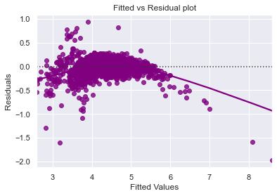

```python
# let's plot the fitted values vs residuals

sns.residplot(
    data=df_pred, x="Fitted Values", y="Residuals", color="purple", lowess=True
)
plt.xlabel("Fitted Values")
plt.ylabel("Residuals")
plt.title("Fitted vs Residual plot")
plt.show()
```

### 3. TEST FOR NORMALITY

**Why the test?**

- Error terms, or residuals, should be normally distributed. If the error terms are not normally distributed, confidence intervals of the coefficient estimates may become too wide or narrow. Once confidence interval becomes unstable, it leads to difficulty in estimating coefficients based on minimization of least squares. Non-normality suggests that there are a few unusual data points that must be studied closely to make a better model.

**How to check normality?**

- The shape of the histogram of residuals can give an initial idea about the normality.
- It can also be checked via a Q-Q plot of residuals. If the residuals follow a normal distribution, they will make a straight line plot, otherwise not.
- Other tests to check for normality includes the Shapiro-Wilk test.
  - Null hypothesis: Residuals are normally distributed
  - Alternate hypothesis: Residuals are not normally distributed

**How to fix if this assumption is not followed?**

- We can apply transformations like log, exponential, arcsinh, etc. as per our data.

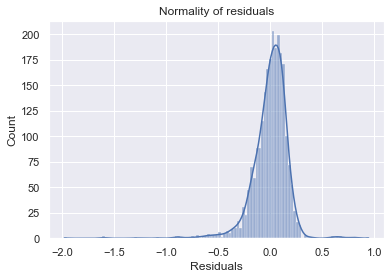

```python
sns.histplot(data=df_pred, x="Residuals", kde=True)
plt.title("Normality of residuals")
plt.show()
```

- The histogram of residuals does have a bell shape.
- Let's check the Q-Q plot.

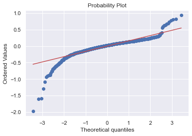

```python
import pylab
import scipy.stats as stats

stats.probplot(df_pred["Residuals"], dist="norm", plot=pylab)
plt.show()
```

- The residuals more or less follow a straight line except for the tails.
- Let's check the results of the Shapiro-Wilk test.

```python
stats.shapiro(df_pred["Residuals"])
```

```
ShapiroResult(statistic=0.8427184820175171, pvalue=2.368194404708941e-43)
```

- Since p-value < 0.05, the residuals are not normal as per the Shapiro-Wilk test.
- Strictly speaking, the residuals are not normal.
- However, as an approximation, we can accept this distribution as close to being normal.
- **So, the assumption is satisfied.**

### 4. TEST FOR HOMOSCEDASTICITY

- **Homoscedascity**: If the variance of the residuals is symmetrically distributed across the regression line, then the data is said to be homoscedastic.
- **Heteroscedascity**: If the variance is unequal for the residuals across the regression line, then the data is said to be heteroscedastic.

**Why the test?**

- The presence of non-constant variance in the error terms results in heteroscedasticity. Generally, non-constant variance arises in presence of outliers.

**How to check for homoscedasticity?**

- The residual vs fitted values plot can be looked at to check for homoscedasticity. In the case of heteroscedasticity, the residuals can form an arrow shape or any other non-symmetrical shape.
- The goldfeldquandt test can also be used. If we get a p-value > 0.05 we can say that the residuals are homoscedastic. Otherwise, they are heteroscedastic.
  - Null hypothesis: Residuals are homoscedastic
  - Alternate hypothesis: Residuals have heteroscedasticity

**How to fix if this assumption is not followed?**

- Heteroscedasticity can be fixed by adding other important features or making transformations.

```python
import statsmodels.stats.api as sms
from statsmodels.compat import lzip

name = ["F statistic", "p-value"]
test = sms.het_goldfeldquandt(df_pred["Residuals"], x_train14)
lzip(name, test)
```

```
[('F statistic', 0.9192494048683093), ('p-value', 0.9240279464011238)]
```

### Observations:

Since p-value > 0.05, we can say that the residuals are homoscedastic. So, this assumption is satisfied.

```python
olsmodel_final = sm.OLS(y_train, x_train14).fit() # Running the final model
print(olsmodel_final.summary())
```

```
                            OLS Regression Results
==============================================================================
Dep. Variable:         used_price_log   R-squared:                       0.907
Model:                            OLS   Adj. R-squared:                  0.906
Method:                 Least Squares   F-statistic:                     1426.
Date:                Sat, 11 Dec 2021   Prob (F-statistic):               0.00
Time:                        08:11:15   Log-Likelihood:                 769.43
No. Observations:                2352   AIC:                            -1505.
Df Residuals:                    2335   BIC:                            -1407.
Df Model:                          16
Covariance Type:            nonrobust
=========================================================================================
                            coef    std err          t      P>|t|      [0.025      0.975]
-----------------------------------------------------------------------------------------
const                   -12.2318      5.724     -2.137      0.033     -23.456      -1.007
screen_size               0.0127      0.002      5.701      0.000       0.008       0.017
main_camera_mp            0.0142      0.001     13.372      0.000       0.012       0.016
selfie_camera_mp          0.0085      0.001      7.931      0.000       0.006       0.011
int_memory               -0.0006   4.91e-05    -11.725      0.000      -0.001      -0.000
release_year              0.0070      0.003      2.471      0.014       0.001       0.013
used_price                0.0058      0.000     43.829      0.000       0.006       0.006
new_price_log             0.1809      0.010     18.352      0.000       0.162       0.200
weight_log                0.1242      0.023      5.416      0.000       0.079       0.169
brand_name_Asus           0.0423      0.019      2.204      0.028       0.005       0.080
brand_name_BlackBerry     0.1703      0.050      3.424      0.001       0.073       0.268
brand_name_Celkon        -0.2014      0.041     -4.880      0.000      -0.282      -0.120
brand_name_Honor          0.0543      0.021      2.577      0.010       0.013       0.096
brand_name_Micromax      -0.0488      0.021     -2.310      0.021      -0.090      -0.007
os_Others                -0.2110      0.022     -9.584      0.000      -0.254      -0.168
4g_yes                    0.0494      0.011      4.361      0.000       0.027       0.072
5g_yes                   -0.1276      0.023     -5.622      0.000      -0.172      -0.083
==============================================================================
Omnibus:                     1314.685   Durbin-Watson:                   1.991
Prob(Omnibus):                  0.000   Jarque-Bera (JB):            33697.017
Skew:                          -2.128   Prob(JB):                         0.00
Kurtosis:                      21.048   Cond. No.                     3.20e+06
==============================================================================

Notes:
[1] Standard Errors assume that the covariance matrix of the errors is correctly specified.
[2] The condition number is large, 3.2e+06. This might indicate that there are
strong multicollinearity or other numerical problems.
```

```python
# Let us write the equation of linear regression
Equation = "used_price_log ="
print(Equation, end=" ")
for i in range(len(x_train14.columns)):
    if i == 0:
        print(olsmodel_final.params[i], "+", end=" ")
    elif i != len(x_train14.columns) - 1:
        print(
            olsmodel_final.params[i],
            "* (",
            x_train14.columns[i],
            ")",
            "+",
            end="  ",
        )
    else:
        print(olsmodel_final.params[i], "* (", x_train14.columns[i], ")")
```

[output not shown]

# Model Performance Evaluation on Test_data

# **Let's check the performance of the model using different metrics.**

- We will be using metric functions defined in sklearn for RMSE, MAE, and $R^2$.
- We will define a function to calculate MAPE and adjusted $R^2$.
  - The mean absolute percentage error (MAPE) measures the accuracy of predictions as a percentage, and can be calculated as the average absolute percent error for each predicted value minus actual values divided by actual values. It works best if there are no extreme values in the data and none of the actual values are 0.
- We will create a function which will print out all the above metrics in one go.

```python
# function to compute adjusted R-squared
def adj_r2_score(predictors, targets, predictions):
    r2 = r2_score(targets, predictions)
    n = predictors.shape[0]
    k = predictors.shape[1]
    return 1 - ((1 - r2) * (n - 1) / (n - k - 1))


# function to compute MAPE
def mape_score(targets, predictions):
    return np.mean(np.abs(targets - predictions) / targets) * 100


# function to compute different metrics to check performance of a regression model
def model_performance_regression(model, predictors, target):
    """
    Function to compute different metrics to check regression model performance

    model: regressor
    predictors: independent variables
    target: dependent variable
    """

    # predicting using the independent variables
    pred = model.predict(predictors)

    r2 = r2_score(target, pred)  # to compute R-squared
    adjr2 = adj_r2_score(predictors, target, pred)  # to compute adjusted R-squared
    rmse = np.sqrt(mean_squared_error(target, pred))  # to compute RMSE
    mae = mean_absolute_error(target, pred)  # to compute MAE
    mape = mape_score(target, pred)  # to compute MAPE

    # creating a dataframe of metrics
    df_perf = pd.DataFrame(
        {
            "RMSE": rmse,
            "MAE": mae,
            "R-squared": r2,
            "Adj. R-squared": adjr2,
            "MAPE": mape,
        },
        index=[0],
    )

    return df_perf
```

```python
# predictions on the test set
pred = olsmod3.predict(x_test14)

df_pred_test = pd.DataFrame({"Actual": y_test, "Predicted": pred})
df_pred_test.sample(10, random_state=1)
```

|  | Actual | Predicted |
| --- | --- | --- |
| 1013 | 3.897924 | 3.924440 |
| 298 | 5.412048 | 5.313945 |
| 1680 | 4.314550 | 4.327187 |
| 1396 | 4.362461 | 4.240104 |
| 1717 | 3.781687 | 3.753270 |
| 1820 | 4.151512 | 4.152776 |
| 509 | 4.244917 | 4.153676 |
| 1403 | 4.363481 | 4.196063 |
| 704 | 4.727299 | 4.708516 |
| 3202 | 4.856474 | 4.764830 |

- We can observe here that our model has returned pretty good prediction results, and the actual and predicted values are comparable.
- We can also visualize comparison result as a bar graph.

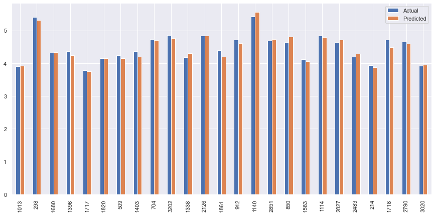

```python
df4 = df_pred_test.sample(25, random_state=1)
df4.plot(kind="bar", figsize=(15, 7))
plt.show()
```

```python
x_train14.columns # checking the columns of final train data
```

```
Index(['const', 'screen_size', 'main_camera_mp', 'selfie_camera_mp',
       'int_memory', 'release_year', 'used_price', 'new_price_log',
       'weight_log', 'brand_name_Asus', 'brand_name_BlackBerry',
       'brand_name_Celkon', 'brand_name_Honor', 'brand_name_Micromax',
       'os_Others', '4g_yes', '5g_yes'],
      dtype='object')
```

```python
x_test14.columns # checking the columns of final test data.
```

```
Index(['const', 'screen_size', 'main_camera_mp', 'selfie_camera_mp',
       'int_memory', 'release_year', 'used_price', 'new_price_log',
       'weight_log', 'brand_name_Asus', 'brand_name_BlackBerry',
       'brand_name_Celkon', 'brand_name_Honor', 'brand_name_Micromax',
       'os_Others', '4g_yes', '5g_yes'],
      dtype='object')
```

### Observation:

- Now the Test and Train data set got the same columns in it.

```python
# checking model performance on train set (seen 70% data)
print("Training Performance\n")
olsmodel_final_train_perf = model_performance_regression(olsmodel_final, x_train14, y_train)
olsmodel_final_train_perf
```

```
Training Performance
```

|  | RMSE | MAE | R-squared | Adj. R-squared | MAPE |
| --- | --- | --- | --- | --- | --- |
| 0 | 0.174457 | 0.11688 | 0.907133 | 0.906457 | 2.930017 |

```python
# checking model performance on test set (seen 30% data)
print("Test Performance\n")
olsmodel_final_test_perf = model_performance_regression(olsmodel_final, x_test14, y_test)
olsmodel_final_test_perf
```

```
Test Performance
```

|  | RMSE | MAE | R-squared | Adj. R-squared | MAPE |
| --- | --- | --- | --- | --- | --- |
| 0 | 0.164323 | 0.114103 | 0.923477 | 0.922163 | 2.891298 |

## Actionable Insights and Recommendations:

### Interpretation of R-squared

- The R-squared value tells us that our model can explain 90.7% of the variance in the training set.

### Interpretation of p-values (P > |t|)

- For each predictor variable there is a null hypothesis and alternate hypothesis.

```
- Null hypothesis : Predictor variable is not significant
- Alternate hypothesis : Predictor variable is significant
```

There are no variables with the P_value>0.05, hence we can say the predictor variable is significant in this data set.

## Hence, we can conclude the model "olsmodel_final" is good for prediction as well as inference purposes.